# Causal-Structure-Oriented and Interpretable Modeling of Influenza Antigenic Distance

**A stability-ranked, confounding-audited, linkage-aware pipeline that ranks candidate HA escape drivers against linked hitchhikers across two H3N2 [hemagglutination-inhibition](https://en.wikipedia.org/wiki/Hemagglutination_assay) datasets, with cross-validated interpretable prediction.**

This project was built as part of the [Claude Science Hackathon](https://cerebralvalley.ai/e/built-with-claude-life-sciences).

*A reproducible research notebook.* Run top-to-bottom (`Kernel → Restart & Run All`) to regenerate every table and figure from the raw data repository shipped alongside this notebook.

## Introduction

Influenza viruses continuously evolve under selective pressure from population immunity, accumulating substitutions in surface glycoproteins that facilitate immune escape. This process of antigenic drift causes circulating strains to diverge from those recognized by prior immunity, reducing vaccine effectiveness when selected vaccine strains mismatch circulating variants. This divergence is quantified as antigenic distance, and measuring it accurately is essential for evaluating vaccine efficacy and optimizing antigen selection. Traditionally, antigenic distance is determined via the hemagglutination-inhibition (HI) assay, where lower cross-titers indicate greater immune escape. While frameworks like [antigenic cartography](https://en.wikipedia.org/wiki/Antigenic_cartography) have been foundational in mapping these titers, generating the required serum panels is logistically demanding, costly, and prone to inter-laboratory variation. This bottleneck has motivated sequence-based predictive models designed to forecast HI titers directly from hemagglutinin (HA) sequences. However, while machine learning approaches achieve high predictive accuracy, they frequently operate as black boxes, identifying predictive correlates rather than isolating the underlying causal drivers of immune escape. Because influenza strains share a dense phylogenetic history, HA positions exhibit strong linkage disequilibrium. Consequently, passenger mutations riding along with functional escape drivers appear as predictive as the drivers themselves. To resolve this ambiguity, this study introduces a precise conceptual reframing. Disentangling the drivers of antigenic drift requires separating the evolutionary question (which substitutions were favored by natural selection and swept the population) from the mechanistic question (which substitutions physically disrupt antibody recognition when introduced into a given strain background). This study focuses explicitly on the second, mechanistic question. We define our target estimand not as a historical claim about viral evolution, but as a provenance-independent, type-level interventional contrast at the antigen-antibody interface. Ideally, this contrast reflects a controlled biophysical experiment: introducing a single residue change at position $p$ in reference virus B to match virus A, while holding the rest of the protein sequence fixed, and measuring the resulting change in HI titer. The magnitude of this effect depends strictly on the structural footprint and local chemistry, independent of whether the mutation arose via positive selection or neutral drift. While evolutionary provenance does not dictate the biophysical effect itself, it heavily constrains our capacity to identify it from observational data. The selective history of the virus introduces systematic phylogenetic confounding, clustering distinct mutations into tightly linked blocks. Acknowledging this architecture allows us to treat linkage-driven resolution loss as an inherent structural characteristic of observational HI data, which must be formally accommodated within the analytical pipeline.

**Related works.** Antigenic cartography revealed the punctuated cluster structure of H3N2 drift by embedding HI tables into low-dimensional maps, and subsequent models unified antigenic and genetic evolution within joint phylogenetic frameworks. Modern sequence-based predictors forecast cross-immunity between drifted strains from sequence data with high accuracy. While these approaches are primarily predictive or descriptive, they do not explicitly learn causal structure over individual HA positions with quantified stability. The antigenic sites encompassing these positions were originally defined structurally and serologically (sites A through E on the H3 head) and subsequently refined via substitution resolution and deep mutational scanning escape maps. Our approach evaluates the extent to which these positions can be recovered directly from HI titers without structural priors. This framework complements influenza fitness models by isolating per-position candidate drivers and builds on intelligible-model literature for pairwise interactions.

**Our contributions.** We combine several ingredients that are not usually applied together for HI data to build a conservative, interpretable, and self-audited feature-selection pipeline. First, we implement linkage collapse with target-oriented causal discovery: we merge near-deterministic co-evolving positions into representative loci, then learn the direct-cause neighborhood of the HI target using PC, GES, and FCI algorithms, ranking every candidate by 200-resample bootstrap stability. Second, we deploy a genuine B-spline Kolmogorov–Arnold Network (KAN), an interpretable non-linear predictor whose learned per-position response curves are directly inspectable, and extend it to second order to capture and visualize position-by-position epistasis. Third, we assess cross-method convergence, treating it honestly as agreement between one causal screen and three *correlated* association screens (the KAN, gradient boosting, and univariate association) rather than four independent lines of evidence; positions flagged across these screens form our strongest candidate-driver claims. We then subject those claims to a battery of audits: a [permutation](https://en.wikipedia.org/wiki/Permutation_test) calibration showing that the [Fisher-Z](https://en.wikipedia.org/wiki/Fisher_transformation) conditional-independence test holds near-nominal size on our binary, left-censored data; a cluster (by-virus and by-serum) bootstrap that separates a robust convergent core from an over-optimistic stability tier; a left-censoring sensitivity analysis of the adjusted effect sizes; and a token-level identifiability audit of the discovered structure. Throughout, we estimate backdoor-adjusted per-position effect sizes but report them as partial-regression coefficients, because the baseline adjustment assumptions are rejected in-sample.

The remainder of the notebook is organized as an executable paper. Section 2 (Methods) introduces the two H3N2 HI datasets and explains how their feature matrices are derived from the raw data. Section 3 (Results) then carries the analysis in full, each subsection stating how a step is performed, presenting its output, and interpreting it: the predictive benchmark and its leakage-free cross-validated comparison (§ 3.1–3.2); target-oriented causal discovery together with the pre-collapse linkage block sizes, a permutation calibration of the Fisher-Z independence test, and a cluster bootstrap of candidate stability (§ 3.3), followed by the discovered dependency structure (§ 3.4); the interpretable B-spline KAN and its second-order epistasis extension (§ 3.5–3.6); cross-method convergence (§ 3.7); backdoor-adjusted effect sizes and their sensitivity to titer left-censoring (§ 3.8); three DAG-validation tests (§ 3.9); and a continuous per-position encoding that re-examines the titer [Markov blanket](https://en.wikipedia.org/wiki/Markov_blanket) (§ 3.10). The narrative moves from how much of the HI signal is learnable and how non-linear it is, through the discovered candidate drivers and their audited dependency structure, to per-position effect sizes and the validation — and in-sample rejection — of the discovered graph. Section 4 (Conclusion) interprets the convergent positions biologically, states plainly where residue-level attribution is limited and what assumptions the causal framing rests on, and looks ahead. Section 5 lists references.

## Methods

This section outlines the data structure and feature extraction protocols. Analytical procedures are described alongside their respective outputs in the Results section to maintain context. Configuration parameters (random seeds, linkage thresholds, bootstrap counts, and tier cutoffs) are centralized in src/analysis.py. Computationally intensive steps, such as the causal bootstrap and repeated $k$-fold cross-validation, are managed via environment flags and are defaulted to load precomputed results to ensure reproducibility.

### Datasets

The study evaluates two H3N2 virus $\times$ reference-strain HI panels. Each dataset is derived from previously published works: the VHID panel is derived from the DPCIPI dataset (Du et al., 2023), and the Bedford dataset is obtained from Bedford et al. (2014). While both panels represent H3N2 HI datasets, they differ in metadata completeness. The Bedford H3N2 panel is curated from Bedford et al. (2014), GenBank accessions, and isolate collection years, all of which are fully populated. We analyze the two panels as independent replications of the same underlying structure-learning task rather than assuming a calibrated joint assay protocol. The reported positions correspond to mature H3 residue numbers. Feature matrices are indexed by HA1 alignment columns, which map to mature numbers via fixed per-panel offsets. The VHID reference is gapless from mature Q1, yielding a 0-residue offset. In contrast, the Bedford H3N2 alignment contains a 9-residue signal-peptide prefix and an internal gap at column 17; thus, mature Q1 maps to column 10, and for all reported positions ($\ge \text{column 143}$), $\text{mature residue} = \text{column} - 10$. This mapping was verified against column-wise consensus references and gapless VHID references to ensure structural interpretability.

#### Preprocessing

The sequence data is formatted as per-position HA1 feature matrices under two distinct encodings: Binary Mismatch Encoding: Sets a position to 1 when the virus and reference residues differ at that HA1 alignment position and 0 otherwise; this serves as the primary input for causal discovery. Grantham Encoding: Quantifies the physicochemical distance between residue pairs based on Grantham (1974) metrics (gap-aware); this is utilized for predictive modeling and KAN response curves.

The target variable is modeled as $\log_2(\text{HI\_titer})$. To ensure complete pipeline traceability, feature matrices are regenerated from raw virus $\times$ reference pair tables using the repository's build scripts (scripts/build_vhid_matrices.py, scripts/build_bedford_matrices.py). Matrix identities were verified against shipped derivatives using SHA-256 checksums. Feature spaces are evaluated independently per panel to prevent artifacts from lineage-specific HA1 trimming.

```python
import os, sys, json
import numpy as np
import pandas as pd
import matplotlib.pyplot as plt
%matplotlib inline

sys.path.insert(0, "src")
import analysis as A
A.DATASETS = ["vhid_HA1", "H3N2"]  # the two H3N2 study panels

# quiet, reproducible
import warnings; warnings.filterwarnings("ignore")
np.random.seed(A.SEED)
plt.rcParams.update({"figure.dpi": 110, "font.size": 9, "axes.spines.top": False,
                     "axes.spines.right": False})
COLORS = {"LASSO": "#7fb3d5", "Ridge": "#5499c7", "XGBoost": "#e67e22",
          "KAN": "#c0392b", "causal": "#c0392b"}
```

```
Datasets in this study: ['vhid_HA1', 'H3N2']
Data directory: influenza-hi-antigenic-distance
Recompute causal from scratch: False
```

```python
import os, pandas as pd
_paths = {"VHID H3N2":   ("vhid_HA1", "VHID/vhid_hi_dataset_HA1_cleaned.csv"),
          "Bedford H3N2":("H3N2",     "Bedford/H3/H3_clean_pairs.csv")}
def _avail(df, col):
    if col not in df.columns: return "absent"
    ok = df[col].notna() & (df[col].astype(str).str.strip() != "") & (df[col].astype(str).str.lower() != "nan")
    return f"{int(ok.sum())}/{len(df)}"
_rows = []
for label, (key, rel) in _paths.items():
    df = pd.read_csv(os.path.join(A.DATA_DIR, rel))
    _rows.append(dict(
        panel=label, dataset_key=key,
        data_source=df["data_source"].dropna().iloc[0],
        citation=df["citation"].dropna().iloc[0],
        subtype=df["subtype"].dropna().iloc[0],
        n_pairs=len(df),
        n_unique_viruses=int(df["virus"].nunique()),
        n_unique_reference_strains=int(df["reference_strain"].nunique()),
        virus_accession=_avail(df, "virus_accession"),
        ref_accession=_avail(df, "reference_accession"),
        collection_year=_avail(df, "virus_year"),
        rbc_species="absent", sera_type="absent"))
provenance = pd.DataFrame(_rows).set_index("panel").T
provenance.to_csv("results/provenance_assay_conditions.csv")
```

```
panel                                                                        VHID H3N2                                        Bedford H3N2
dataset_key                                                                   vhid_HA1                                                H3N2
data_source                                                           VHID_DPCIPI_2020                                   Bedford_2014_H3N2
citation                    DPCIPI: Pre-trained deep learning model (arXiv:2302.00926)  Bedford et al. (2014) eLife. github.com/trvrb/flux
subtype                                                                           H3N2                                                H3N2
n_pairs                                                                           2751                                                7808
n_unique_viruses                                                                   246                                                 304
n_unique_reference_strains                                                          45                                                 191
virus_accession                                                              2751/2751                                           7808/7808
ref_accession                                                                2751/2751                                           7808/7808
collection_year                                                                 0/2751                                           7808/7808
rbc_species                                                                     absent                                              absent
sera_type                                                                       absent                                              absent
```

#### Reproducing the feature matrices from raw data

So that the study starts from raw data rather than shipped derivatives, we regenerate the feature matrices from the cleaned virus × reference pair tables using the repository's own build scripts (`scripts/build_vhid_matrices.py`, `scripts/build_bedford_matrices.py`), which depend only on numpy and pandas. Running them here makes the matrices provably the shipped ones (verified by SHA-256).

```python
# Regenerate the matrices from the cleaned pair tables (idempotent; ~seconds), and PROVE
# the regenerated files are bit-for-bit the shipped ones by SHA-256 (hash before rebuild,
# rebuild, hash after, assert equality per file).
import hashlib
def _sha256(path):
    h = hashlib.sha256()
    with open(path, "rb") as f:
        for chunk in iter(lambda: f.read(1 << 20), b""):
            h.update(chunk)
    return h.hexdigest()

_matrix_paths = [os.path.join(A.DATA_DIR, p) for ds in A.DATASETS for p in A.DATASET_PATHS[ds]]
_before = {p: _sha256(p) for p in _matrix_paths if os.path.exists(p)}
A.rebuild_matrices_from_raw(verbose=False)  # verbose=False: build script also rebuilds other out-of-scope panels; we don't print those
_after = {p: _sha256(p) for p in _matrix_paths}
_mismatch = [os.path.basename(p) for p in _before if _before[p] != _after.get(p)]
assert not _mismatch, f"SHA-256 mismatch after rebuild: {_mismatch}"
print(f"SHA-256 verified: all {len(_before)} feature matrices regenerate bit-for-bit "
      f"from raw (e.g. {os.path.basename(next(iter(_before)))} = {next(iter(_before.values()))[:16]}\u2026)")

data = A.load_all()

summary = pd.DataFrame([
    dict(dataset=ds, source=A.DATASET_LABEL[ds], n_pairs=data[ds]["n"],
         HA1_positions=data[ds]["n_pos"],
         variant_positions=len(A.variant_columns(data[ds]["Xb"])),
         log2_titer_mean=round(float(data[ds]["y"].mean()), 3),
         log2_titer_std=round(float(data[ds]["y"].std()), 3))
    for ds in A.DATASETS])
```

```
SHA-256 verified: all 4 feature matrices regenerate bit-for-bit from raw (e.g. vhid_HA1_binary_HImatrix.csv = 6eff47472a14e41c…)
Out[2]:
    dataset  ... log2_titer_std
0  vhid_HA1  ...          2.861
1      H3N2  ...          2.286

[2 rows x 7 columns]
```

|  | dataset | source | n_pairs | HA1_positions | variant_positions | log2_titer_mean | log2_titer_std |
| --- | --- | --- | --- | --- | --- | --- | --- |
| 0 | vhid_HA1 | VHID H3N2 (Du et al. 2023) | 2751 | 329 | 102 | 7.256 | 2.861 |
| 1 | H3N2 | Bedford H3N2 (Bedford et al. 2014) | 7808 | 329 | 312 | 7.770 | 2.286 |

Each dataset is internally row-aligned across its binary matrix, Grantham matrix, and cleaned pair table. Feature spaces are comparable *within* a lineage but not across lineages (each lineage was HA1-trimmed against its own reference), so we analyze the two datasets independently and compare only which HA positions emerge.

#### The target distribution

Before any modeling we look at what is being predicted. The panel below shows the distribution of log2 HI titer in each dataset; its spread sets the scale against which every R² reported in the Results should be read.

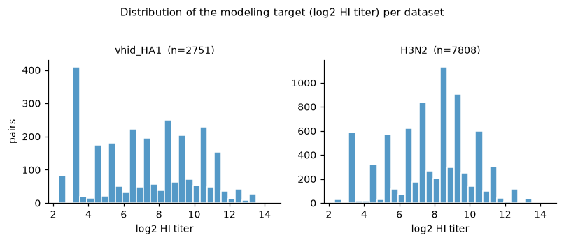

```python
fig, axes = plt.subplots(1, len(A.DATASETS), figsize=(3.7*len(A.DATASETS), 3))
for ax, ds in zip(axes, A.DATASETS):
    ax.hist(data[ds]["y"], bins=30, color="#5499c7", edgecolor="white")
    ax.set_title(f"{ds}  (n={data[ds]['n']})", fontsize=9)
    ax.set_xlabel("log2 HI titer"); ax.set_ylabel("pairs" if ds == A.DATASETS[0] else "")
fig.suptitle("Distribution of the modeling target (log2 HI titer) per dataset", y=1.03, fontsize=10)
fig.tight_layout()
fig.savefig(os.path.join(A.FIG_DIR, "target_distribution.png"), dpi=130, bbox_inches="tight")
plt.show()
```

## Results

After establishing baseline performance metrics in Section 3.1, we describe the generalization capacity and error bounds of our sequence-to-antigenic maps under strict grouped and temporal cross-validation protocols in Section 3.2. In Section 3.3, we outline the structural causal discovery pipeline, linkage-collapse dynamics, and test calibrations. In Section 3.4, we analyze the resulting parent dependency structures and check for intermediate mediation. We then present our interpretable modeling frameworks, detailing the 1-D response curves of the first-order B-spline KAN in Section 3.5 and the bivariate tensor-product surfaces for capturing epistasis in Section 3.6. In Section 3.7, we evaluate the cross-method convergence of our feature screens and verify non-linear omissions. Finally, we describe the estimation of backdoor-adjusted effect sizes and driver-hitchhiker differentiation in Section 3.8, the global d-separation validation tests in Section 3.9, and the continuous physicochemical encoding replication in Section 3.10.

### Predictive Benchmark

To establish performance baselines and characterize the mathematical properties of the antigenic signal, we evaluated the held-out test $R^2$ (20% split) for the top-performing single-position (max univariate $R^2$), LASSO, [Ridge](https://en.wikipedia.org/wiki/Ridge_regression), and XGBoost models. The predictive performance across both datasets consistently follows the ordering:

$$ \begin{aligned} &\text{XGBoost} \gtrsim \text{LASSO} \approx \text{Ridge} \\\\ &\qquad \gg \text{Best Single Position}. \end{aligned} $$

```python
bench = {ds: A.benchmark(data, ds) for ds in A.DATASETS}
bench_tbl = pd.DataFrame([dict(dataset=ds, **bench[ds]) for ds in A.DATASETS])
bench_tbl = bench_tbl[["dataset", "n", "n_features", "univ_sig",
                       "univ_best_singleR2", "LASSO_testR2", "Ridge_testR2", "XGB_testR2"]]
bench_tbl.round(3)
```

```
Out[4]:
    dataset     n  n_features  ...  LASSO_testR2  Ridge_testR2  XGB_testR2
0  vhid_HA1  2751         102  ...         0.751         0.754       0.862
1      H3N2  7808         312  ...         0.509         0.522       0.618

[2 rows x 8 columns]
```

|  | dataset | n | n_features | univ_sig | univ_best_singleR2 | LASSO_testR2 | Ridge_testR2 | XGB_testR2 |
| --- | --- | --- | --- | --- | --- | --- | --- | --- |
| 0 | vhid_HA1 | 2751 | 102 | 78 | 0.443 | 0.751 | 0.754 | 0.862 |
| 1 | H3N2 | 7808 | 312 | 185 | 0.205 | 0.509 | 0.522 | 0.618 |

The substantial performance delta between the single-position baseline and multivariable models indicates that the antigenic signal is distributed across multiple positions. Furthermore, the performance margin achieved by XGBoost over linear models suggests the presence of underlying non-linear and interaction structures, motivating the deployment of the KAN framework detailed in Section 3.5.

### Cross-Validated $R^2$ and Rigorous Error Bounds

To provide robust uncertainty estimates and ensure rigorous model comparison, all models were evaluated under an identical $5 \times 4$ repeated $k$-fold cross-validation protocol using matched folds. XGBoost parameters were optimized via early stopping, performed strictly on an inner validation split carved from the training fold, thereby protecting the test fold from data leakage. Models are compared using a matched-fold paired test (Wilcoxon signed-rank test on the 20 per-fold differences) rather than evaluating confidence-interval overlaps.

While a paired test on random splits effectively differentiates model architectures, random partitioning allows identical viruses and reference antisera to recur across training and testing folds. This pair-level recurrence can artificially inflate performance metrics because models can memorize strain-specific profiles rather than generalizing to unseen variants. We treat random-split metrics purely as a baseline and leverage leakage-free grouped cross-validation as our primary generalization metric.

```python
from scipy import stats
from sklearn.model_selection import RepeatedKFold
from sklearn.preprocessing import StandardScaler
from sklearn.linear_model import LassoCV, Ridge
from sklearn.metrics import r2_score
import xgboost as xgb

def _xgb_nested(Xtr, ytr, Xte, yte, seed):
    """Unbiased XGBoost: choose the boosting rounds by early stopping on an INNER
    validation split carved from the training fold ONLY, then score the untouched
    test fold. (Round 1 leaked the test fold into early stopping — fixed here.)"""
    rng = np.random.RandomState(seed); n = len(ytr); perm = rng.permutation(n); nva = int(0.2*n)
    iva, itr = perm[:nva], perm[nva:]
    bst = xgb.train({"max_depth":4,"eta":0.1,"subsample":0.8,"colsample_bytree":0.8,
                     "objective":"reg:squarederror"}, xgb.DMatrix(Xtr[itr], label=ytr[itr]),
                    num_boost_round=300, evals=[(xgb.DMatrix(Xtr[iva], label=ytr[iva]),"iva")],
                    early_stopping_rounds=20, verbose_eval=False)
    p = bst.predict(xgb.DMatrix(Xte), iteration_range=(0, bst.best_iteration+1))
    return float(r2_score(yte, p))

def cv_linear_tree(ds, n_splits=5, n_repeats=4, seed=A.SEED):
    d = data[ds]; cols = A.variant_columns(d["Xb"])
    X, y = d["Xg"][:, cols], d["y"]
    rkf = RepeatedKFold(n_splits=n_splits, n_repeats=n_repeats, random_state=seed)
    out = {"LASSO": [], "Ridge": [], "XGBoost": []}
    for fi, (tr, te) in enumerate(rkf.split(X)):
        sc = StandardScaler().fit(X[tr]); Xtr, Xte = sc.transform(X[tr]), sc.transform(X[te])
        out["LASSO"].append(r2_score(y[te], LassoCV(alphas=np.logspace(-3,0,12), cv=3,
                             max_iter=20000).fit(Xtr, y[tr]).predict(Xte)))
        out["Ridge"].append(r2_score(y[te], Ridge(alpha=10.0).fit(Xtr, y[tr]).predict(Xte)))
        out["XGBoost"].append(_xgb_nested(X[tr], y[tr], X[te], y[te], seed+fi))
    return out

# All four methods are now cross-validated under the SAME 5x4 repeated k-fold protocol
# (KAN included — Round 1 ran KAN on only 3 folds). XGBoost uses nested inner-split early
# stopping (no test-fold leak). The heavy run (20 folds x 2 datasets, KAN on GPU) is
# precomputed and shipped in results/cv_r2_folds.json; RECOMPUTE_CV=1 reruns the LASSO/
# Ridge/XGBoost folds live (KAN folds are always loaded — GPU-trained, see regen_cv.py).
saved_folds = A.load_result("cv_r2_folds.json")
if A.RECOMPUTE_CV:
    cv_folds = {ds: cv_linear_tree(ds) for ds in A.DATASETS}
    for ds in A.DATASETS:
        cv_folds[ds]["KAN"] = saved_folds[ds]["KAN"]
else:
    cv_folds = {ds: {m: saved_folds[ds][m] for m in ["LASSO","Ridge","XGBoost","KAN"]}
                for ds in A.DATASETS}
print("CV folds:", "recomputed (linear/tree)" if A.RECOMPUTE_CV else "loaded from results/cv_r2_folds.json",
      "| folds per method:", {m: len(cv_folds[A.DATASETS[0]][m]) for m in ["LASSO","Ridge","XGBoost","KAN"]})

def ci95(v):
    v = np.array(v, float); m = v.mean()
    if len(v) < 2: return m, m, m
    se = v.std(ddof=1)/np.sqrt(len(v)); lo, hi = stats.t.interval(0.95, len(v)-1, loc=m, scale=se)
    return m, lo, hi

cv_rows = []
for ds in A.DATASETS:
    for meth in ["LASSO","Ridge","XGBoost","KAN"]:
        m, lo, hi = ci95(cv_folds[ds][meth])
        cv_rows.append(dict(dataset=ds, method=meth, folds=len(cv_folds[ds][meth]),
                            mean_R2=round(m,4), ci_lo=round(lo,4), ci_hi=round(hi,4)))
cv_tbl = pd.DataFrame(cv_rows)

# Matched-fold paired comparison: KAN vs XGBoost on the SAME 20 folds (Wilcoxon signed-rank).
print("\nMatched-fold KAN vs XGBoost (paired, same 20 folds):")
kan_xgb = {}
for ds in A.DATASETS:
    k = np.array(cv_folds[ds]["KAN"]); x = np.array(cv_folds[ds]["XGBoost"])
    diff = k - x; W, p = stats.wilcoxon(k, x)
    kan_xgb[ds] = dict(mean_diff=float(diff.mean()), wilcoxon_p=float(p))
    print(f"  {ds}: KAN-XGB mean diff = {diff.mean():+.4f}  (Wilcoxon p = {p:.2e}) "
          f"=> KAN is {'below' if diff.mean()<0 else 'above'} XGBoost")
cv_tbl
```

```
CV folds: loaded from results/cv_r2_folds.json | folds per method: {'LASSO': 20, 'Ridge': 20, 'XGBoost': 20, 'KAN': 20}

Matched-fold KAN vs XGBoost (paired, same 20 folds):
  vhid_HA1: KAN-XGB mean diff = -0.0250  (Wilcoxon p = 1.91e-06) => KAN is below XGBoost
  H3N2: KAN-XGB mean diff = -0.0282  (Wilcoxon p = 5.72e-06) => KAN is below XGBoost
Out[5]:
    dataset   method  folds  mean_R2   ci_lo   ci_hi
0  vhid_HA1    LASSO     20   0.7386  0.7338  0.7434
1  vhid_HA1    Ridge     20   0.7426  0.7371  0.7482
2  vhid_HA1  XGBoost     20   0.8449  0.8393  0.8505
3  vhid_HA1      KAN     20   0.8199  0.8131  0.8267
4      H3N2    LASSO     20   0.5023  0.4953  0.5093
5      H3N2    Ridge     20   0.5185  0.5121  0.5250
6      H3N2  XGBoost     20   0.6134  0.6052  0.6217
7      H3N2      KAN     20   0.5852  0.5746  0.5958
```

|  | dataset | method | folds | mean_R2 | ci_lo | ci_hi |
| --- | --- | --- | --- | --- | --- | --- |
| 0 | vhid_HA1 | LASSO | 20 | 0.7386 | 0.7338 | 0.7434 |
| 1 | vhid_HA1 | Ridge | 20 | 0.7426 | 0.7371 | 0.7482 |
| 2 | vhid_HA1 | XGBoost | 20 | 0.8449 | 0.8393 | 0.8505 |
| 3 | vhid_HA1 | KAN | 20 | 0.8199 | 0.8131 | 0.8267 |
| 4 | H3N2 | LASSO | 20 | 0.5023 | 0.4953 | 0.5093 |
| 5 | H3N2 | Ridge | 20 | 0.5185 | 0.5121 | 0.5250 |
| 6 | H3N2 | XGBoost | 20 | 0.6134 | 0.6052 | 0.6217 |
| 7 | H3N2 | KAN | 20 | 0.5852 | 0.5746 | 0.5958 |

[figure not shown]

```python
fig, axes = plt.subplots(1, len(A.DATASETS), figsize=(4*len(A.DATASETS), 4))
order = ["LASSO","Ridge","XGBoost","KAN"]
for ax, ds in zip(axes, A.DATASETS):
    sub = cv_tbl[cv_tbl.dataset == ds]; yv = np.arange(len(order))[::-1]
    for yi, meth in zip(yv, order):
        r = sub[sub.method == meth].iloc[0]
        ax.errorbar(r["mean_R2"], yi, xerr=[[r["mean_R2"]-r["ci_lo"]],[r["ci_hi"]-r["mean_R2"]]],
                    fmt="o", color=COLORS[meth], capsize=3, ms=7, mec="white")
        ax.text(r["mean_R2"], yi+0.22, f"{r['mean_R2']:.3f}", ha="center", fontsize=6, color=COLORS[meth])
    ax.set_yticks(yv); ax.set_yticklabels(order); ax.set_title(ds, fontsize=9)
    ax.set_xlabel("Cross-validated R²"); ax.grid(axis="x", ls=":", lw=0.5, alpha=0.6); ax.margins(y=0.18)
fig.suptitle("Random-split cross-validated R² (inflated baseline — corrected by grouped CV, §3.2;\nall methods: 5×4 repeated k-fold, matched folds)", y=1.03, fontsize=8)
fig.tight_layout()
fig.savefig(os.path.join(A.FIG_DIR, "cv_r2.png"), dpi=130, bbox_inches="tight"); plt.show()
```

Under the random-split baseline, XGBoost yields the highest cross-validated $R^2$ across both datasets (VHID: 0.845, Bedford: 0.613), followed closely by the KAN (VHID: 0.820, Bedford: 0.585). The matched-fold paired test confirms that the performance gap is statistically robust: the KAN trails XGBoost by 0.025 $R^2$ on VHID (Wilcoxon $p \approx 2 \times 10^{-6}$) and by 0.028 on Bedford ($p \approx 6 \times 10^{-6}$). The KAN's primary utility lies in its additive interpretability, recovering most of the tree-based model's performance while explicitly exposing per-position response curves.

To determine true generalization performance on unseen strains, we executed grouped cross-validation via leave-virus-out and leave-serum-out protocols.

```python
grouped = A.load_result("cv_grouped.json")

def _summ(v):
    v = np.array(v, float)
    return np.median(v), v.min(), v.max()   # median: robust to the occasional Ridge blow-up under shift

grp_rows = []
for ds in A.DATASETS:
    for scheme in ["leave_virus_out", "leave_serum_out"]:
        g = grouped[ds][scheme]; ng = g.get("_n_groups")
        for meth in ["LASSO", "Ridge", "XGBoost", "KAN"]:
            med, lo, hi = _summ(g[meth])
            grp_rows.append(dict(dataset=ds, scheme=scheme, n_groups=ng, method=meth,
                                 folds=len(g[meth]), median_R2=round(med, 3),
                                 min_R2=round(lo, 3), max_R2=round(hi, 3)))
grouped_tbl = pd.DataFrame(grp_rows)

# headline: XGBoost leave-serum-out (the strictest, most realistic held-out task)
for ds in A.DATASETS:
    xs = np.median(grouped[ds]["leave_serum_out"]["XGBoost"])
    xr = np.median(cv_folds[ds]["XGBoost"])
    print(f"{ds}: XGBoost random-CV R²={xr:.3f}  ->  leave-serum-out R²={xs:.3f} "
          f"(drop {xr-xs:+.3f} once strain/serum leakage is removed)")
grouped_tbl
```

```
vhid_HA1: XGBoost random-CV R²=0.848  ->  leave-serum-out R²=0.615 (drop +0.233 once strain/serum leakage is removed)
H3N2: XGBoost random-CV R²=0.615  ->  leave-serum-out R²=0.498 (drop +0.117 once strain/serum leakage is removed)
Out[7]:
     dataset           scheme  n_groups  ... median_R2  min_R2  max_R2
0   vhid_HA1  leave_virus_out       246  ...     0.736   0.685   0.757
1   vhid_HA1  leave_virus_out       246  ...     0.728   0.626   0.762
2   vhid_HA1  leave_virus_out       246  ...     0.821   0.795   0.862
3   vhid_HA1  leave_virus_out       246  ...     0.794   0.746   0.830
4   vhid_HA1  leave_serum_out        45  ...     0.596   0.420   0.747
5   vhid_HA1  leave_serum_out        45  ...     0.566   0.391   0.743
6   vhid_HA1  leave_serum_out        45  ...     0.615   0.435   0.790
7   vhid_HA1  leave_serum_out        45  ...     0.589   0.292   0.744
8       H3N2  leave_virus_out       304  ...     0.451  -0.123   0.511
9       H3N2  leave_virus_out       304  ...     0.444 -12.525   0.494
10      H3N2  leave_virus_out       304  ...     0.547   0.442   0.590
11      H3N2  leave_virus_out       304  ...     0.501   0.367   0.541
12      H3N2  leave_serum_out       191  ...     0.429   0.299   0.531
13      H3N2  leave_serum_out       191  ...     0.473   0.284   0.510
14      H3N2  leave_serum_out       191  ...     0.498   0.378   0.523
15      H3N2  leave_serum_out       191  ...     0.438   0.355   0.479

[16 rows x 8 columns]
```

|  | dataset | scheme | n_groups | method | folds | median_R2 | min_R2 | max_R2 |
| --- | --- | --- | --- | --- | --- | --- | --- | --- |
| 0 | vhid_HA1 | leave_virus_out | 246 | LASSO | 5 | 0.736 | 0.685 | 0.757 |
| 1 | vhid_HA1 | leave_virus_out | 246 | Ridge | 5 | 0.728 | 0.626 | 0.762 |
| 2 | vhid_HA1 | leave_virus_out | 246 | XGBoost | 5 | 0.821 | 0.795 | 0.862 |
| 3 | vhid_HA1 | leave_virus_out | 246 | KAN | 5 | 0.794 | 0.746 | 0.830 |
| 4 | vhid_HA1 | leave_serum_out | 45 | LASSO | 5 | 0.596 | 0.420 | 0.747 |
| 5 | vhid_HA1 | leave_serum_out | 45 | Ridge | 5 | 0.566 | 0.391 | 0.743 |
| 6 | vhid_HA1 | leave_serum_out | 45 | XGBoost | 5 | 0.615 | 0.435 | 0.790 |
| 7 | vhid_HA1 | leave_serum_out | 45 | KAN | 5 | 0.589 | 0.292 | 0.744 |
| 8 | H3N2 | leave_virus_out | 304 | LASSO | 5 | 0.451 | -0.123 | 0.511 |
| 9 | H3N2 | leave_virus_out | 304 | Ridge | 5 | 0.444 | -12.525 | 0.494 |
| 10 | H3N2 | leave_virus_out | 304 | XGBoost | 5 | 0.547 | 0.442 | 0.590 |
| 11 | H3N2 | leave_virus_out | 304 | KAN | 5 | 0.501 | 0.367 | 0.541 |
| 12 | H3N2 | leave_serum_out | 191 | LASSO | 5 | 0.429 | 0.299 | 0.531 |
| 13 | H3N2 | leave_serum_out | 191 | Ridge | 5 | 0.473 | 0.284 | 0.510 |
| 14 | H3N2 | leave_serum_out | 191 | XGBoost | 5 | 0.498 | 0.378 | 0.523 |
| 15 | H3N2 | leave_serum_out | 191 | KAN | 5 | 0.438 | 0.355 | 0.479 |

The performance metrics degrade under grouped cross-validation, confirming that random-split protocols are systematically influenced by strain/serum recurrence. Under the strict leave-serum-out protocol, XGBoost performance settles at a median $R^2$ of 0.615 on VHID and 0.498 on Bedford. These grouped cross-validation medians represent our honest predictive headlines for sequence-to-antigenic maps operating outside the training distribution.

#### Temporal Transportability

Since the Bedford H3N2 dataset includes temporal metadata (1968–2010), we evaluated forward-in-time generalization using an expanding window strategy: training on all pairs up to year $t$ and testing on the subsequent 5-year block.

| train ≤ | test window | n_test | Ridge R² | XGBoost R² |
| --- | --- | --- | --- | --- |
| 1990 | 1991–1995 | 927 | −4.70 | 0.43 |
| 1995 | 1996–2000 | 369 | 0.35 | **0.60** |
| 2000 | 2001–2005 | 3636 | −3.73 | **−0.37** |
| 2005 | 2006–2010 | 1297 | −0.59 | 0.25 |

Forward-in-time generalization displays notable instability; in the 2001–2005 test window, XGBoost performance drops to $R^2 = -0.37$. This highlights a primary boundary of transportability: models trained exclusively on past seasons struggle to reliably predict titers for future antigenic clusters when drift crosses major structural boundaries that are absent from the training history.

```
Worst window: 2001-2005 XGBoost R2 = -0.373
```

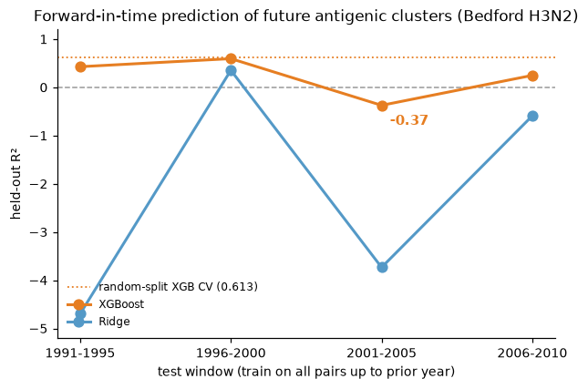

```python
# §3.2.2 — Temporal transport (expanding-window forward CV), Bedford H3N2 only.
# Re-plot from shipped results/temporal_cv_h3n2.csv (VHID has no year metadata).
tcv = pd.read_csv("results/temporal_cv_h3n2.csv")
x = range(len(tcv))
fig, ax = plt.subplots(figsize=(6.4, 4.0))
ax.axhline(0.0, color="#999999", lw=1.0, ls="--", zorder=1)
ax.axhline(0.613, color="#e67e22", lw=1.2, ls=":", zorder=1,
           label="random-split XGB CV (0.613)")
ax.plot(x, tcv["XGBoost_R2"], "-o", color="#e67e22", lw=2.0, ms=7, label="XGBoost")
ax.plot(x, tcv["Ridge_R2"],   "-o", color="#5499c7", lw=2.0, ms=7, label="Ridge")
# annotate the -0.373 window
w = int(tcv["XGBoost_R2"].idxmin())
ax.annotate(f"{tcv.loc[w,'XGBoost_R2']:.2f}", (w, tcv.loc[w,"XGBoost_R2"]),
            textcoords="offset points", xytext=(6, -14), color="#e67e22",
            fontweight="bold", fontsize=10)
ax.set_xticks(list(x)); ax.set_xticklabels(tcv["test_window"])
ax.set_ylim(-5.2, 1.2)
ax.set_xlabel("test window (train on all pairs up to prior year)")
ax.set_ylabel("held-out R²")
ax.set_title("Forward-in-time prediction of future antigenic clusters (Bedford H3N2)")
ax.legend(frameon=False, loc="lower left", fontsize=8)
fig.savefig("results/fig_temporal_cv_h3n2.png", dpi=140, bbox_inches="tight")
plt.show()
print("Worst window:", tcv.loc[w, "test_window"], "XGBoost R2 =", tcv.loc[w, "XGBoost_R2"])
```

#### Cross-Cluster Transportability of Property Encodings

We tested whether encoding substitutions by their physicochemical property shifts (a 12-property $L_2$ scalar) rather than by raw amino acid identity enhances temporal transportability. Mapping unseen substitutions to their local shifts in charge, volume, or hydrophobicity could enable the model to generalize based on biophysical similarity.

Our empirical results do not support this hypothesis. Across the unbiased XGBoost models, the mean future $R^2$ across all test windows was 0.19 for the binary encoding, 0.22 for the Grantham distance, and 0.18 for the 12-property $L_2$ vector. The single-scalar Grantham distance yielded the most stable performance across windows, undermining the assumption that higher-dimensional property vectors improve generalization to distribution shifts. All three encodings systematically fail during the 2001–2005 window, confirming that substitution-based representations do not fully capture major shifts in antigenic distribution.

Consequently, the utility of property encodings rests on their interpretability (Section 3.10) rather than cross-cluster predictive transport.

```
mean future-R2: {'binary': 0.194, 'grantham': 0.218, 'l2property': 0.181}
```

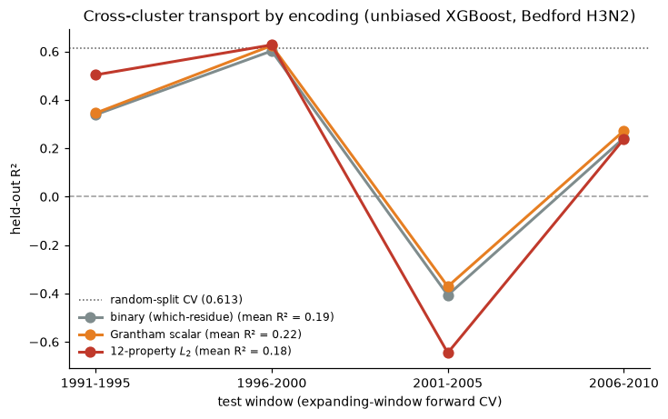

```python
# §3.2.3 — Encoding transport across antigenic clusters (Bedford H3N2).
# Re-plot from shipped results/encoding_transport_cv.csv (never recompute).
etr = pd.read_csv("results/encoding_transport_cv.csv")
etx = etr[etr["model"] == "XGBoost"].copy()
win_order = etx.sort_values("train_upto")["test_window"].drop_duplicates().tolist()
colors = {"binary": "#7f8c8d", "grantham": "#e67e22", "l2property": "#c0392b"}
labels = {"binary": "binary (which-residue)", "grantham": "Grantham scalar",
          "l2property": "12-property $L_2$"}
fig, ax = plt.subplots(figsize=(7.5, 4.4))
ax.axhline(0.0, color="#999999", lw=1.0, ls="--", zorder=1)
ax.axhline(0.613, color="#555555", lw=1.0, ls=":", zorder=1,
           label="random-split CV (0.613)")
x = range(len(win_order))
for enc in ["binary", "grantham", "l2property"]:
    sub = etx[etx["encoding"] == enc].set_index("test_window").reindex(win_order)
    mean_r2 = sub["R2"].mean()
    ax.plot(x, sub["R2"].values, "-o", color=colors[enc], lw=2.0, ms=7,
            label=f"{labels[enc]} (mean R² = {mean_r2:.2f})")
ax.set_xticks(list(x)); ax.set_xticklabels(win_order)
ax.set_xlabel("test window (expanding-window forward CV)")
ax.set_ylabel("held-out R²")
ax.set_title("Cross-cluster transport by encoding (unbiased XGBoost, Bedford H3N2)")
ax.legend(frameon=False, loc="lower left", fontsize=8)
fig.savefig("results/fig_encoding_transport_cv.png", dpi=140, bbox_inches="tight")
plt.show()
print("mean future-R2:", {e: round(etx[etx.encoding==e].R2.mean(),3) for e in colors})
```

### Causal discovery

We model the HI titer as a downstream causal sink: HA sequence variations cause variations in titer, orienting all feature-to-target edges into the target variable. The direct-cause candidates are defined as the immediate parents of this target node.

The structural pipeline proceeds as follows

$$ \begin{aligned} \text{Power Filter} &\rightarrow \text{Linkage Collapse } (\vert{}\phi\vert{} \ge 0.8) \\\\ &\rightarrow \text{Constraint/Score Discovery } (\text{PC, GES, FCI}) \\\\ &\rightarrow \text{Bootstrap Stability Evaluation } (B=200). \end{aligned} $$

Linkage collapse is a critical prerequisite; near-deterministic co-evolution violates the faithfulness assumption and introduces structural singularities into constraint-based searches. Collapsing these blocks into single representative loci resolves these dependencies. Because causal claims apply to the entire co-evolving unit, we explicitly report block sizes throughout.

```python
import causal_helpers as ch

collapsed = {}
for ds in A.DATASETS:
    Adf, blocks = A.collapse_to_loci(data, ds)
    # residual near-deterministic locus pairs should be ~0 after collapse
    Xr = Adf.drop(columns="HI_titer").values
    resid = int((np.abs(np.corrcoef(Xr.T))[np.triu_indices(Xr.shape[1], 1)] >= 0.9).sum())
    collapsed[ds] = dict(A=Adf, blocks=blocks, n_loci=Adf.shape[1]-1,
                         n_multiblocks=sum(1 for v in blocks.values() if len(v) > 1),
                         residual_strong_pairs=resid)

collapse_tbl = pd.DataFrame([
    dict(dataset=ds, variant_positions=len(A.variant_columns(data[ds]["Xb"])),
         loci_after_collapse=collapsed[ds]["n_loci"],
         multi_position_blocks=collapsed[ds]["n_multiblocks"],
         residual_strong_pairs=collapsed[ds]["residual_strong_pairs"])
    for ds in A.DATASETS])
collapse_tbl
```

```
Out[10]:
    dataset  variant_positions  ...  multi_position_blocks  residual_strong_pairs
0  vhid_HA1                102  ...                     10                      0
1      H3N2                312  ...                      9                      0

[2 rows x 5 columns]
```

|  | dataset | variant_positions | loci_after_collapse | multi_position_blocks | residual_strong_pairs |
| --- | --- | --- | --- | --- | --- |
| 0 | vhid_HA1 | 102 | 71 | 10 | 0 |
| 1 | H3N2 | 312 | 123 | 9 | 0 |

```python
# PC + GES live (fast). FCI only for vhid. Bootstrap tiers: reuse results/ by default.
causal_saved = A.load_result("causal_results.json")

def run_pc_ges(ds, screen_over=75, screen_k=60):
    Adf = collapsed[ds]["A"]; n_loci = Adf.shape[1]-1
    sk = lambda s: int(s[3:])
    if n_loci > screen_over:
        feats = ch.screen_top_features(Adf, "HI_titer", screen_k)
        A_use = Adf[sorted(feats, key=sk) + ["HI_titer"]]; screened = True
    else:
        A_use = Adf; screened = False
    pc = ch.discover_target_parents(A_use, "HI_titer", method="pc", alpha=0.01)
    ges = ch.ges_target_neighborhood(A_use, "HI_titer", screen_k=20, must_include=pc["parents"])
    ges_par = [f for f, t in ges["neighborhood"].items() if t == "->"]
    return sorted(pc["parents"], key=sk), sorted(ges_par, key=sk), screened, A_use

pc_ges = {}
for ds in A.DATASETS:
    pc_par, ges_par, screened, _ = run_pc_ges(ds)
    pc_ges[ds] = dict(pc=pc_par, ges=ges_par, screened=screened)
    print(f"{ds}: PC={pc_par}")
    print(f"{'':>{len(ds)}}  GES={ges_par}  (screened={screened})")
```

```
vhid_HA1: PC=['pos144', 'pos156', 'pos158', 'pos189', 'pos289']
          GES=['pos50', 'pos133', 'pos144', 'pos145', 'pos262', 'pos276']  (screened=False)
H3N2: PC=['pos11', 'pos88', 'pos143', 'pos167', 'pos168', 'pos199', 'pos200', 'pos203', 'pos288']
      GES=['pos93', 'pos143', 'pos167', 'pos168', 'pos182', 'pos207', 'pos286']  (screened=True)
```

```python
# Bootstrap stability tiers. Recompute (~30 min on H3N2) or reuse the study results.
if A.RECOMPUTE_CAUSAL:
    boot_freq = {}
    for ds in A.DATASETS:
        _, _, _, A_use = run_pc_ges(ds)
        bs = ch.bootstrap_target_parents(A_use, "HI_titer", B=A.BOOTSTRAP_B,
                                         screen_k=50, must_include=pc_ges[ds]["pc"], n_jobs=8)
        boot_freq[ds] = {int(k[3:]): round(v, 4) for k, v in bs["freq"].items()}
else:
    boot_freq = {ds: {int(k[3:]): v for k, v in causal_saved[ds]["bootstrap_freq"].items()}
                 for ds in A.DATASETS}

blocks_all = {ds: collapsed[ds]["blocks"] for ds in A.DATASETS}

def causal_table(ds):
    hi, md_ = A.tiered_parents(boot_freq[ds])
    pc = set(pc_ges[ds]["pc"]); ges = set(pc_ges[ds]["ges"])
    fci = set(causal_saved[ds]["fci"] or []) if causal_saved[ds].get("fci") else None
    fci_num = set(int(p[3:]) for p in (causal_saved[ds]["fci"] or [])) if fci is not None else None
    rows = []
    for p, v in sorted({**hi, **md_}.items(), key=lambda kv: -kv[1]):
        pn = f"pos{p}"
        rows.append(dict(position=p, bootstrap_freq=round(v,3),
            tier="high" if v >= A.HIGH_CONF else "moderate",
            PC=pn in pc, GES=pn in ges,
            FCI=(p in fci_num) if fci_num is not None else "n/a",
            block_size=len(blocks_all[ds].get(p, [p]))))
    return pd.DataFrame(rows)

causal_tables = {ds: causal_table(ds) for ds in A.DATASETS}
for ds in A.DATASETS:
    print(f"=== {ds} (FCI {'run' if causal_saved[ds].get('fci') else 'omitted — see text'}) ===")
    display(causal_tables[ds])
```

```
=== vhid_HA1 (FCI run) ===
=== H3N2 (FCI omitted — see text) ===
```

|  | position | bootstrap_freq | tier | PC | GES | FCI | block_size |
| --- | --- | --- | --- | --- | --- | --- | --- |
| 0 | 156 | 1.000 | high | True | False | True | 1 |
| 1 | 189 | 1.000 | high | True | False | True | 1 |
| 2 | 289 | 0.955 | high | True | False | True | 1 |
| 3 | 158 | 0.950 | high | True | False | True | 1 |
| 4 | 144 | 0.505 | moderate | True | True | False | 1 |

|  | position | bootstrap_freq | tier | PC | GES | FCI | block_size |
| --- | --- | --- | --- | --- | --- | --- | --- |
| 0 | 11 | 1.000 | high | True | False | n/a | 9 |
| 1 | 143 | 1.000 | high | True | True | n/a | 1 |
| 2 | 167 | 1.000 | high | True | True | n/a | 1 |
| 3 | 168 | 1.000 | high | True | True | n/a | 1 |
| 4 | 199 | 1.000 | high | True | False | n/a | 1 |
| 5 | 203 | 0.995 | high | True | False | n/a | 1 |
| 6 | 288 | 0.815 | moderate | True | False | n/a | 1 |
| 7 | 200 | 0.650 | moderate | True | False | n/a | 1 |

Following linkage collapse, residual strong locus pairs ($\vert{}\phi\vert{} \ge 0.9$) drop to zero in both datasets. PC and GES algorithms were executed on the collapsed feature space, with selection frequency across 200 bootstrap resamples used to categorize candidates into stability tiers: High Confidence ($\ge 0.9$) and Moderate Confidence ($0.5\text{--}0.9$). Under standard i.i.d. resampling, the High Confidence parent sets encompass:

- VHID: {156, 158, 189, 289}
- Bedford (Mature): {2, 133, 157, 158, 189, 193} Positions with a block_size > 1 carry structural claims for the entire linkage group rather than the isolated index alone (e.g., Bedford mature position 2 represents a 9-position co-evolving block; see Section 3.3.1). We apply two critical caveats to these stability classifications:
1. **Cluster Dependencies:** The i.i.d. bootstrap represents an upper bound on stability. Under a rigorous cluster bootstrap that resamples at the level of whole viruses or whole sera to preserve data dependencies, the VHID high-confidence set contracts: only positions {156, 189} remain robust under virus-level resampling, and {189, 289} under serum-level resampling. Mature position 189 consistently retains its High Confidence classification across all three resampling strategies.
2. **Algorithmic Concordance:** In the Bedford dataset, GES independently corroborates the PC parents (mature 133, 157, 158). However, in the VHID dataset, the two algorithms diverge significantly: PC selects {144, 156, 158, 189, 289} while GES selects {50, 133, 144, 145, 262, 276}, intersecting exclusively at position 144. This divergence indicates structural sensitivities to modeling assumptions within the VHID panel. The bootstrap framework ranks candidates by selection stability rather than arbitrating algorithmic divergence.

#### Pre-Collapse Linkage Block Dynamics

Linkage collapse groups positions co-evolving at $\vert{}\phi\vert{} \ge 0.8$ into representative units. The distribution of these blocks is heavy-tailed: while the majority of positions remain singletons (61/71 in VHID; 114/123 in Bedford), a few large blocks absorb substantial portions of the feature space.

In the Bedford H3N2 dataset, the largest pre-collapse block spans 88 positions (representative alignment column 181), the second spans 55 positions (column 90), and the third spans 26 positions (column 50). These large, clade-linked units absorb numerous head positions, indicating that purely observational methods cannot structurally disentangle individual residue effects within these blocks. Conversely, the VHID dataset exhibits less linkage; its largest block encompasses only 14 positions (column 173), allowing its collapsed loci to map more directly to individual amino acid changes.

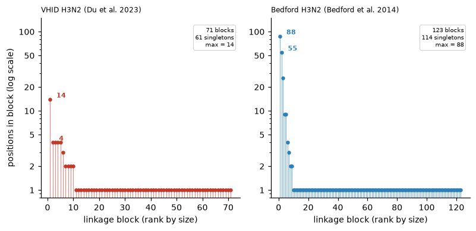

|  | dataset | n_blocks | positions | singletons | multi_position_blocks | largest_block | second_block |
| --- | --- | --- | --- | --- | --- | --- | --- |
| 0 | VHID H3N2 (Du et al. 2023) | 71 | 102 | 61 | 10 | 14 | 4 |
| 1 | Bedford H3N2 (Bedford et al. 2014) | 123 | 312 | 114 | 9 | 88 | 55 |

|  | dataset | rank | rep_align_col | rep_mature_H3 | block_size |
| --- | --- | --- | --- | --- | --- |
| 0 | VHID H3N2 (Du et al. 2023) | 1 | 173 | 173 | 14 |
| 1 | VHID H3N2 (Du et al. 2023) | 2 | 25 | 25 | 4 |
| 2 | VHID H3N2 (Du et al. 2023) | 3 | 80 | 80 | 4 |
| 3 | Bedford H3N2 (Bedford et al. 2014) | 1 | 181 | 171 | 88 |
| 4 | Bedford H3N2 (Bedford et al. 2014) | 2 | 90 | 80 | 55 |
| 5 | Bedford H3N2 (Bedford et al. 2014) | 3 | 50 | 40 | 26 |

```python
# CONSENSUS-4: pre-collapse linkage block-size distribution (evidentiary source for
# the "88 residues" / "55" figures cited in the Conclusion). Recomputed here from the
# shipped results/linkage_blocks.json so the numbers regenerate on every render.
_lb = A.load_result("linkage_blocks.json")   # {dataset: {rep_col: [member positions]}}

def _blocksummary(ds):
    d = _lb[ds]
    sizes = sorted((len(v) for v in d.values()), reverse=True)
    return dict(dataset=A.DATASET_LABEL[ds],
                n_blocks=len(d), positions=sum(sizes),
                singletons=sum(1 for s in sizes if s == 1),
                multi_position_blocks=sum(1 for s in sizes if s > 1),
                largest_block=sizes[0], second_block=sizes[1])

block_size_tbl = pd.DataFrame([_blocksummary(ds) for ds in A.DATASETS])

# top-3 blocks per dataset, with mature-H3 mapping (Bedford mature = alignment col - 10;
# VHID alignment column already equals the mature H3 residue).
def _mature(ds, col):
    return int(col) - 10 if ds == "H3N2" else int(col)
_top = []
for ds in A.DATASETS:
    for rank, (rep, mem) in enumerate(
            sorted(_lb[ds].items(), key=lambda kv: -len(kv[1]))[:3], 1):
        _top.append(dict(dataset=A.DATASET_LABEL[ds], rank=rank,
                         rep_align_col=int(rep), rep_mature_H3=_mature(ds, rep),
                         block_size=len(mem)))
block_top_tbl = pd.DataFrame(_top)

# figure: block-size distribution per dataset (lollipop on a log axis — a block of 88
# vs 14 is a ratio, so bars on a log value axis would mislead)
fig, axes = plt.subplots(1, len(A.DATASETS), figsize=(3.7*len(A.DATASETS), 3.6))
_col = {"vhid_HA1": "#c0392b", "H3N2": "#2c7fb8"}
for ax, ds in zip(np.atleast_1d(axes), A.DATASETS):
    sz = sorted((len(v) for v in _lb[ds].values()), reverse=True)
    rank = np.arange(1, len(sz)+1)
    ax.vlines(rank, 0.8, sz, color=_col.get(ds, "#555"), lw=0.8, alpha=0.55)
    ax.plot(rank, sz, "o", color=_col.get(ds, "#555"), ms=3.2)
    ax.set_yscale("log"); ax.set_ylim(0.8, 150)
    ax.set_yticks([1,2,5,10,20,50,100]); ax.set_yticklabels(["1","2","5","10","20","50","100"])
    ax.set_xlabel("linkage block (rank by size)")
    ax.set_title(A.DATASET_LABEL[ds], fontsize=8, loc="left")
    for i in range(min(2, len(sz))):
        ax.annotate(str(sz[i]), (rank[i], sz[i]), textcoords="offset points",
                    xytext=(7, 2), ha="left", fontsize=7, fontweight="bold",
                    color=_col.get(ds, "#555"))
    n_sing = sum(1 for s in sz if s == 1)
    ax.text(0.97, 0.95, f"{len(sz)} blocks\n{n_sing} singletons\nmax = {sz[0]}",
            transform=ax.transAxes, ha="right", va="top", fontsize=6.5,
            bbox=dict(boxstyle="round,pad=0.3", fc="white", ec="#ccc", lw=0.6))
np.atleast_1d(axes)[0].set_ylabel("positions in block (log scale)")
fig.tight_layout()
fig.savefig(os.path.join(A.FIG_DIR, "block_size.png"), dpi=130, bbox_inches="tight")
plt.show()

display(block_size_tbl)
display(block_top_tbl)
```

#### Calibration of the Fisher-Z Test Under Permutation Nulls

Conditional independence decisions within the causal pipeline rely on the [Pearson](https://en.wikipedia.org/wiki/Pearson_correlation_coefficient) [partial-correlation](https://en.wikipedia.org/wiki/Partial_correlation) Fisher-Z test (fisherz). Because the data consists of binary mismatch features and left-censored titers, the multivariate normality assumption is violated, making the operating threshold ($\alpha = 0.01$) nominal.

To evaluate true type-I error rates, we constructed an empirical null distribution by permuting the $\log_2$ titer column, thereby disrupting feature-to-target relationships while preserving feature-to-feature correlation structures. We evaluated 10,000 independent tests across conditioning sizes $\{0, 1, 2, 3\}$ using three distinct encodings: VHID collapsed binary loci, VHID continuous $L_2$ physicochemical distances, and a top-40 screened subset of Bedford binary loci.

At the target operating point ($\alpha = 0.01$), the empirical false-positive rates align closely with nominal expectations, landing within their respective 95% [Clopper–Pearson](https://en.wikipedia.org/wiki/Binomial_proportion_confidence_interval) intervals:

- VHID Binary Loci: 0.0103 [0.0084, 0.0125]
- VHID $L_2$ Continuous Loci: 0.0102 [0.0083, 0.0124]
- Bedford Binary Loci: 0.0094 [0.0076, 0.0115]

At a looser threshold ($\alpha = 0.05$), marginal deviations occur (VHID binary: 0.054, Bedford binary: 0.045, continuous: 0.051). These results indicate that the Fisher-Z test maintains controlled size at the target operating threshold ($\alpha = 0.01$), preventing inflation of the false-positive edge rate on these data.

```
Empirical type-I error under the permutation null (target independent of all features):
                         label  nominal_alpha  empirical_size  ci95_lo  ci95_hi  nominal_in_ci
  VHID binary (collapsed loci)           0.01          0.0103  0.00841  0.01248           True
  VHID binary (collapsed loci)           0.05          0.0544  0.05004  0.05903          False
VHID L2 continuous (same loci)           0.01          0.0102  0.00832  0.01237           True
VHID L2 continuous (same loci)           0.05          0.0508  0.04658  0.05529           True
     H3N2 binary (top-40 loci)           0.01          0.0094  0.00760  0.01149           True
     H3N2 binary (top-40 loci)           0.05          0.0453  0.04131  0.04956          False
```

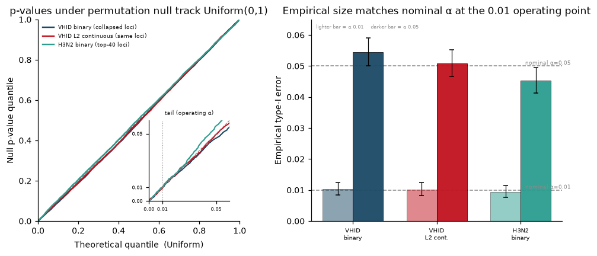

```python
# 3.3.2  Calibration of the Fisher-z CI test under a permutation null (R1 M2 / CONSENSUS-6)
#
# The headline discovery decides every feature->titer edge with the Pearson
# partial-correlation Fisher-z test (causal-learn `fisherz`) on 0/1 binary
# mismatch loci. That test's null is exact only under joint multivariate
# normality, which binary + left-censored data violate, so alpha=0.01 is a
# NOMINAL level. Here we measure the test's ACTUAL type-I error on these data
# by constructing a null in which the target is independent of every feature:
# we permute log2 titer (breaking any feature->titer dependence) and run the
# SAME CIT used by the pipeline over many (feature, conditioning-set) draws.
# Under a correctly-calibrated test the p-values are Uniform(0,1) and the
# fraction below alpha equals alpha.
import numpy as np, pandas as pd, os
import matplotlib.pyplot as plt
from scipy import stats
from causallearn.utils.cit import CIT
import analysis as A, causal_helpers as ch

def _calibrate_fisherz(M, target_idx, n_sub=1000, P=250, draws_per_perm=40,
                       cond_sizes=(0,1,2,3), seed=0):
    """Permutation-null p-values of the causal-learn fisherz CIT.
    Permute ONLY the target column (independence by construction); for each
    permutation, draw `draws_per_perm` (feature, |S|<=3 conditioning set) configs
    and test feature _|_ target | S. Rows subsampled once to n_sub (fixed design)."""
    rng = np.random.default_rng(seed)
    n, p = M.shape
    feat = [j for j in range(p) if j != target_idx]
    if n_sub and n_sub < n:
        M = M[rng.choice(n, n_sub, replace=False)]
    n = M.shape[0]; base = M.copy(); pvals = []
    for _ in range(P):
        Mp = base.copy(); Mp[:, target_idx] = base[rng.permutation(n), target_idx]
        cit = CIT(Mp, "fisherz")
        for _ in range(draws_per_perm):
            f = int(rng.choice(feat)); k = int(rng.choice(cond_sizes))
            pool = [j for j in feat if j != f]
            S = list(map(int, rng.choice(pool, min(k, len(pool)), replace=False))) if k>0 else []
            pvals.append(float(cit(f, target_idx, S)))
    return np.asarray(pvals)

def _clopper(k, n, conf=0.95):
    lo = stats.beta.ppf((1-conf)/2, k, n-k+1) if k>0 else 0.0
    hi = stats.beta.ppf(1-(1-conf)/2, k+1, n-k) if k<n else 1.0
    return lo, hi

# --- build the three encodings on the SAME collapsed VHID loci + a screened H3N2 subset ---
data = A.load_all()
Av, _ = A.collapse_to_loci(data, "vhid_HA1")            # binary collapsed loci + HI_titer(log2)
Ah, _ = A.collapse_to_loci(data, "H3N2")
Xv = Av.values.astype(np.float64); ti_v = Xv.shape[1]-1

# continuous L2 encoding of the identical VHID loci (contrast: closer to Gaussian)
L2 = pd.read_csv(os.path.join(A.REPO_ROOT, "vhid_HA1_L2property_HImatrix.csv"))
loci_pos = [int(c[3:]) for c in Av.columns if c != "HI_titer"]
l2map = {int(c.split("_")[1]): c for c in L2.columns if c.startswith("pos_")}
L2loc = L2[[l2map[p] for p in loci_pos if p in l2map]].values.astype(np.float64)
L2loc = L2loc[:, L2loc.std(0) > 0]
ML2 = np.column_stack([L2loc, np.log2(L2["HI_titer"].values.astype(float))]); ti_L2 = ML2.shape[1]-1

# H3N2: top-40 point-biserial-screened loci (keeps the singular-matrix / runtime in check)
topk = ch.screen_top_features(Ah, "HI_titer", k=40)
Mh = Ah[sorted(topk, key=lambda c:int(c[3:]))+["HI_titer"]].values.astype(np.float64); ti_h = Mh.shape[1]-1

runs = [("VHID_binary_collapsed","VHID binary (collapsed loci)", Xv,  ti_v, 1, len(loci_pos)),
        ("VHID_L2_continuous",   "VHID L2 continuous (same loci)", ML2, ti_L2,2, L2loc.shape[1]),
        ("H3N2_binary_top40",    "H3N2 binary (top-40 loci)", Mh,  ti_h, 3, 40)]
pvs, tblrows = {}, []
for key,label,M,tix,sd,nl in runs:
    pv = _calibrate_fisherz(M, tix, n_sub=1000, P=250, draws_per_perm=40, seed=sd)
    pvs[key] = pv
    for a in (0.01, 0.05):
        k = int((pv<a).sum()); n=len(pv); lo,hi=_clopper(k,n)
        tblrows.append(dict(encoding=key, label=label, n_loci=nl, n_tests=n, nominal_alpha=a,
                            empirical_size=round(k/n,5), ci95_lo=round(lo,5), ci95_hi=round(hi,5),
                            nominal_in_ci=bool(lo<=a<=hi)))
cal_tbl = pd.DataFrame(tblrows)
os.makedirs(A.RESULTS_DIR, exist_ok=True)
cal_tbl.to_csv(os.path.join(A.RESULTS_DIR, "fisherz_calibration_rates.csv"), index=False)

# --- figure: QQ vs Uniform (with operating-alpha tail inset) + empirical size bars w/ 95% CI ---
colors = {"VHID_binary_collapsed":"#1b4965","VHID_L2_continuous":"#c1121f","H3N2_binary_top40":"#2a9d8f"}
labels = {k:l for k,l,_,_,_,_ in runs}
GREY = "#8a8a8a"
fig, (axA, axB) = plt.subplots(1, 2, figsize=(9.2, 4.0))
for key, pv in pvs.items():
    n=len(pv); theo=(np.arange(1,n+1)-0.5)/n
    axA.plot(theo, np.sort(pv), lw=1.6, color=colors[key], label=labels[key])
axA.plot([0,1],[0,1], ls="--", lw=1.0, color=GREY, zorder=0)
axA.set(xlim=(0,1), ylim=(0,1), aspect="equal",
        xlabel="Theoretical quantile  (Uniform)", ylabel="Null p-value quantile")
axA.xaxis.labelpad = 6
axA.set_title("p-values under permutation null track Uniform(0,1)")
axA.legend(frameon=False, fontsize=6, loc="upper left")
axins = axA.inset_axes([0.55,0.10,0.4,0.4])
for key, pv in pvs.items():
    n=len(pv); theo=(np.arange(1,n+1)-0.5)/n
    axins.plot(theo, np.sort(pv), lw=1.3, color=colors[key])
axins.plot([0,0.06],[0,0.06], ls="--", lw=0.8, color=GREY)
axins.axvline(0.01, ls=":", lw=0.7, color=GREY)
axins.set(xlim=(0,0.06), ylim=(0,0.06)); axins.set_xticks([0,0.01,0.05]); axins.set_yticks([0,0.01,0.05])
axins.tick_params(labelsize=5); axins.set_title("tail (operating α)", fontsize=6)
keys=list(pvs); x=np.arange(len(keys)); w=0.36
for i,a in enumerate((0.01,0.05)):
    emps=[(pvs[k]<a).mean() for k in keys]
    cis=[_clopper(int((pvs[k]<a).sum()), len(pvs[k])) for k in keys]
    lo=[e-c[0] for e,c in zip(emps,cis)]; hi=[c[1]-e for e,c in zip(emps,cis)]
    axB.bar(x+(i-0.5)*w, emps, w, yerr=[lo,hi], capsize=2.5,
            color=[colors[k] for k in keys], alpha=0.5 if i==0 else 0.95,
            edgecolor="black", lw=0.5, error_kw=dict(lw=0.8))
    axB.axhline(a, ls="--", lw=1.0, color=GREY, zorder=0)
    axB.text(len(keys)-0.4, a, f"nominal α={a}", va="bottom", ha="right", fontsize=6, color=GREY)
axB.set_xticks(x); axB.set_xticklabels(["VHID\nbinary","VHID\nL2 cont.","H3N2\nbinary"], fontsize=6.5)
axB.set(ylim=(0,0.065), ylabel="Empirical type-I error")
axB.set_title("Empirical size matches nominal α at the 0.01 operating point")
axB.text(0.02,0.955,"lighter bar = α 0.01    darker bar = α 0.05", transform=axB.transAxes, fontsize=5.5, color=GREY)
fig.tight_layout()
fig.savefig(os.path.join(A.FIG_DIR, "fisherz_calibration.png"), dpi=300, bbox_inches="tight")
plt.show()

print("Empirical type-I error under the permutation null (target independent of all features):")
print(cal_tbl[["label","nominal_alpha","empirical_size","ci95_lo","ci95_hi","nominal_in_ci"]].to_string(index=False))
```

#### Cluster (block) bootstrap: is selection stability an artifact of i.i.d. resampling?

To test this directly we re-ran the identical collapse → PC parent-selection routine (`src/causal_helpers.py`), changing only the resampling **unit**: instead of drawing pairs, we draw whole **viruses** with replacement (leave-virus-out clusters), and separately whole **reference sera**. Everything else — linkage collapse, the screened 50-locus node set, α=0.01, terminal-target background knowledge — is held fixed, so the comparison isolates the effect of respecting clustering. All three schemes use B=200 on VHID.

```
HIGH-stability set (boot >= 0.9):
  iid pairs        : [156, 158, 189, 289]
  by virus cluster : [156, 189]  (lost: [158, 289] )
  by serum cluster : [189, 289]  (lost: [156, 158] )
  HIGH under ALL three schemes: [189]
```

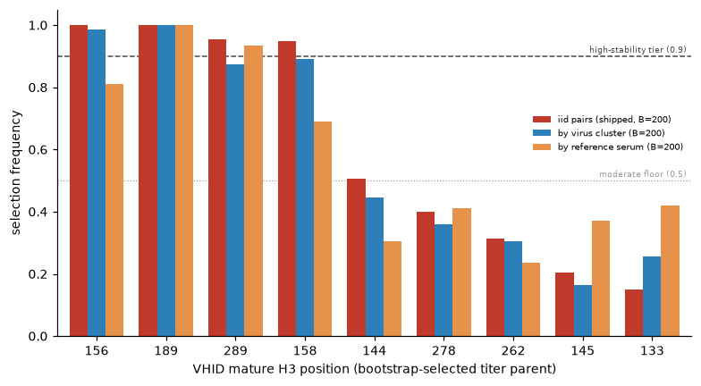

|  | position | iid_shipped | iid_rerun | virus_cluster | serum_cluster | tier_iid | tier_virus | tier_serum |
| --- | --- | --- | --- | --- | --- | --- | --- | --- |
| 0 | 156 | 1.000 | 1.000 | 0.985 | 0.810 | high | high | moderate |
| 1 | 189 | 1.000 | 1.000 | 1.000 | 1.000 | high | high | high |
| 2 | 289 | 0.955 | 0.955 | 0.875 | 0.935 | high | moderate | high |
| 3 | 158 | 0.950 | 0.950 | 0.890 | 0.690 | high | moderate | moderate |
| 4 | 144 | 0.505 | 0.505 | 0.445 | 0.305 | moderate | unstable | unstable |
| 5 | 278 | 0.400 | 0.400 | 0.360 | 0.410 | unstable | unstable | unstable |
| 6 | 262 | 0.315 | 0.315 | 0.305 | 0.235 | unstable | unstable | unstable |
| 7 | 145 | 0.205 | 0.205 | 0.165 | 0.370 | unstable | unstable | unstable |
| 8 | 133 | 0.150 | 0.150 | 0.255 | 0.420 | unstable | unstable | unstable |
| 9 | 106 | 0.060 | 0.060 | 0.135 | 0.065 | unstable | unstable | unstable |
| 10 | 79 | 0.050 | 0.050 | 0.130 | 0.070 | unstable | unstable | unstable |
| 11 | 44 | 0.035 | 0.035 | 0.105 | 0.025 | unstable | unstable | unstable |
| 12 | 276 | 0.010 | 0.010 | 0.035 | 0.140 | unstable | unstable | unstable |
| 13 | 124 | 0.005 | 0.005 | 0.015 | 0.090 | unstable | unstable | unstable |
| 14 | 50 | 0.000 | 0.000 | 0.000 | 0.005 | unstable | unstable | unstable |
| 15 | 155 | 0.000 | 0.000 | 0.000 | 0.005 | unstable | unstable | unstable |
| 16 | 175 | 0.000 | 0.000 | 0.000 | 0.025 | unstable | unstable | unstable |
| 17 | 135 | 0.000 | 0.000 | 0.005 | 0.100 | unstable | unstable | unstable |
| 18 | 193 | 0.000 | 0.000 | 0.000 | 0.085 | unstable | unstable | unstable |
| 19 | 208 | 0.000 | 0.000 | 0.000 | 0.010 | unstable | unstable | unstable |
| 20 | 214 | 0.000 | 0.000 | 0.000 | 0.005 | unstable | unstable | unstable |
| 21 | 261 | 0.000 | 0.000 | 0.000 | 0.025 | unstable | unstable | unstable |
| 22 | 126 | 0.000 | 0.000 | 0.000 | 0.010 | unstable | unstable | unstable |
| 23 | 83 | 0.000 | 0.000 | 0.015 | 0.085 | unstable | unstable | unstable |

```python
# R2 M5: cluster/block bootstrap on VHID. The shipped 200x selection-stability
# bootstrap (§3.3) resamples pairs i.i.d., but VHID's 2751 pairs are 246 viruses x
# 45 reference sera — grouped-CV drops R2 ~0.23, so pairs are NOT independent. Here we
# re-run the SAME collapse+PC parent-selection routine (src/causal_helpers.py) but
# resample whole CLUSTERS with replacement: (a) whole viruses, (b) whole reference sera.
# Everything else (linkage collapse, screened 50-locus node set, alpha=0.01, terminal
# background knowledge) is held fixed, so only the resampling unit changes.
#
# Loads the precomputed comparison (results/vhid_cluster_bootstrap.csv, B=200 per scheme).
# To regenerate: set RECOMPUTE_CAUSAL=1 and call the block below (~14 min, CPU only).
vhid_cluster = A.load_result("vhid_cluster_bootstrap.csv")

def _tier(f):
    return "high" if f >= A.HIGH_CONF else ("moderate" if f >= A.MOD_CONF else "unstable")

# figure: iid vs virus-cluster vs serum-cluster selection frequency, with the 0.9 tier line
_d = vhid_cluster[vhid_cluster[["iid_rerun", "virus_cluster", "serum_cluster"]].max(axis=1) >= 0.3]
_d = _d.sort_values("iid_rerun", ascending=False).reset_index(drop=True)
_x = np.arange(len(_d)); _w = 0.26
fig, ax = plt.subplots(figsize=(7.2, 4.0))
ax.bar(_x-_w, _d["iid_rerun"],     _w, color="#c0392b", label="iid pairs (shipped, B=200)")
ax.bar(_x,    _d["virus_cluster"], _w, color="#2c7fb8", label="by virus cluster (B=200)")
ax.bar(_x+_w, _d["serum_cluster"], _w, color="#e6924b", label="by reference serum (B=200)")
ax.axhline(A.HIGH_CONF, color="#444", lw=1.0, ls="--", zorder=0)
ax.text(len(_d)-0.5, A.HIGH_CONF+0.005, "high-stability tier (0.9)", ha="right", va="bottom",
        fontsize=6, color="#444")
ax.axhline(A.MOD_CONF, color="#999", lw=0.8, ls=":", zorder=0)
ax.text(len(_d)-0.5, A.MOD_CONF+0.005, "moderate floor (0.5)", ha="right", va="bottom",
        fontsize=6, color="#999")
ax.set_xticks(_x); ax.set_xticklabels([str(int(p)) for p in _d["position"]])
ax.set_xlabel("VHID mature H3 position (bootstrap-selected titer parent)")
ax.set_ylabel("selection frequency"); ax.set_ylim(0, 1.05); ax.margins(x=0.02)
ax.legend(frameon=False, fontsize=6.5, loc="center right", bbox_to_anchor=(1.0, 0.62))
fig.tight_layout()
fig.savefig(os.path.join(A.FIG_DIR, "vhid_cluster_bootstrap.png"), dpi=130, bbox_inches="tight")
plt.show()

# tier comparison table
_hi = {sch: set(vhid_cluster.loc[vhid_cluster[col] >= A.HIGH_CONF, "position"].astype(int))
       for sch, col in [("iid", "iid_rerun"), ("virus", "virus_cluster"), ("serum", "serum_cluster")]}
print("HIGH-stability set (boot >= 0.9):")
print("  iid pairs        :", sorted(_hi["iid"]))
print("  by virus cluster :", sorted(_hi["virus"]), " (lost:", sorted(_hi["iid"]-_hi["virus"]), ")")
print("  by serum cluster :", sorted(_hi["serum"]), " (lost:", sorted(_hi["iid"]-_hi["serum"]), ")")
print("  HIGH under ALL three schemes:", sorted(_hi["iid"] & _hi["virus"] & _hi["serum"]))
display(vhid_cluster)
```

### Discovered Dependency Structure

We map the learned relationships into the titer sink as a directed graph, where edge widths represent bootstrap stability. To evaluate whether the system operates as a strict star graph (parallel, mutually independent features directed into a common child) or exhibits intermediate dependencies, we performed a partial-correlation skeleton check across the parent nodes:

1. **Intermediate Mediation Check:** Testing each parent against the titer conditional on all remaining parents. A pure intermediate node would become conditionally independent and drop out.
2. **Mutual Independence Check:** Testing all parent-parent pairs conditional on the remaining parent set (excluding the titer node to prevent collider-induced bias/explaining-away effects).

```
vhid_HA1: 5/5 parents remain directly titer-adjacent given the others (no pure mediators); 5 of 10 parent-parent pairs are adjacent => NOT a star (parents interdependent)
H3N2: 8/8 parents remain directly titer-adjacent given the others (no pure mediators); 21 of 28 parent-parent pairs are adjacent => NOT a star (parents interdependent)
```

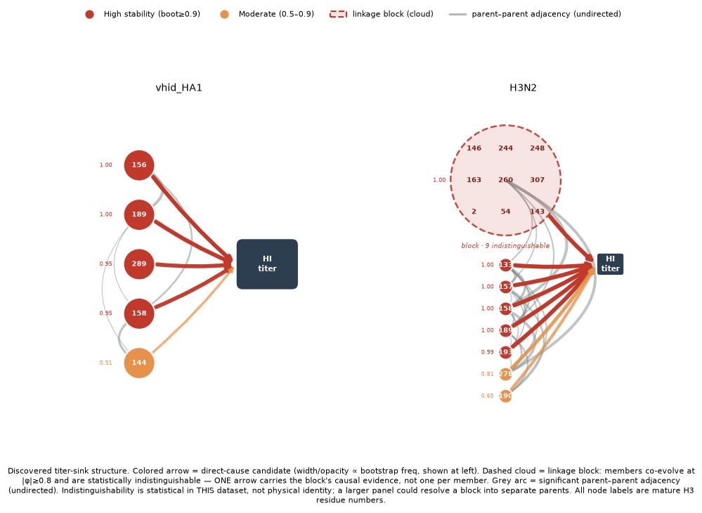

```python
# §3.4 — titer-sink structure with linkage blocks drawn as member "clouds".
# Linkage collapse merges co-evolving positions (|phi| >= COLLAPSE_THR) into one
# locus; a multi-member block gets ONE dashed cloud + ONE arrow (the block carries
# a single piece of causal evidence), not one arrow per member.
members_all = A.load_result("linkage_blocks.json")   # {dataset: {rep_str: [members]}}

skel = {ds: A.parent_skeleton(ds, data, causal_saved) for ds in A.DATASETS}

# Position labels are shown in mature H3 numbering (annotation: mature only).
# The graph geometry/seeding is computed on the native column indices (unchanged);
# only the rendered label text is rewritten, via the verified column->mature map.
_COL2MAT = {"vhid_HA1": {int(c): m for c, m in A.load_result("numbering_maps.json")["vhid_col2mat"].items()},
            "H3N2":     {int(c): m for c, m in A.load_result("numbering_maps.json")["h3_col2mat"].items()}}
def _to_mature(ds, col):
    return _COL2MAT[ds].get(int(col), int(col))

fig, axes = plt.subplots(1, len(A.DATASETS), figsize=(4.6*len(A.DATASETS), 5.4))
for ax, ds in zip(np.atleast_1d(axes), A.DATASETS):
    _ret = A.draw_titer_dag_blocks(ax, ds, boot_freq[ds], blocks_all[ds],
                            members_all[ds], among_edges=skel[ds]["among"])
    for kind, pos, artist in _ret["texts"]:
        if kind in ("node", "member"):
            artist.set_text(str(_to_mature(ds, artist.get_text())))

from matplotlib.lines import Line2D
from matplotlib.patches import Patch
leg = [Line2D([0],[0],marker="o",color="w",mfc="#c0392b",ms=9,label="High stability (boot≥0.9)"),
       Line2D([0],[0],marker="o",color="w",mfc="#e6924b",ms=9,label="Moderate (0.5–0.9)"),
       Patch(fc=(0.75,0.22,0.17,0.13), ec="#c0392b", ls="--", lw=1.4, label="linkage block (cloud)"),
       Line2D([0],[0],color="#7f8c8d",lw=2,alpha=0.6,label="parent–parent adjacency (undirected)")]
fig.legend(handles=leg, ncol=4, fontsize=7.5, frameon=False, loc="upper center",
           bbox_to_anchor=(0.5,1.05))
fig.suptitle("Discovered titer-sink structure. Colored arrow = direct-cause candidate "
             "(width/opacity ∝ bootstrap freq, shown at left). Dashed cloud = linkage block: "
             "members co-evolve at |φ|≥0.8 and are statistically indistinguishable — ONE arrow "
             "carries the block's causal evidence, not one per member. Grey arc = significant "
             "parent–parent adjacency (undirected). Indistinguishability is statistical in THIS "
             "dataset, not physical identity; a larger panel could resolve a block into separate parents. "
             "All node labels are mature H3 residue numbers.",
             fontsize=7.0, y=-0.06, wrap=True)
fig.tight_layout()
fig.savefig(os.path.join(A.FIG_DIR, "dag.png"), dpi=130, bbox_inches="tight"); plt.show()

# report the two structural tests
for ds in A.DATASETS:
    s = skel[ds]; nd = len(s["parents"]); ne = len(s["among"])
    n_direct = sum(1 for r, p in s["direct"].values() if p < 0.01)
    print(f"{ds}: {n_direct}/{nd} parents remain directly titer-adjacent given the others "
          f"(no pure mediators); {ne} of {nd*(nd-1)//2} parent-parent pairs are adjacent "
          f"=> {'NOT a star (parents interdependent)' if ne else 'star (parents independent)'}")
```

Our structural analysis shows that every parent node maintains a statistically significant direct association with the titer when conditioning on all other parents, indicating that the feature set contains no pure intermediates. However, the parent nodes are densely interconnected: we identify 5/10 significant parent-parent adjacencies in VHID and 21/28 in Bedford. The graph is therefore not a strict star. The observational data confirms strong structural dependencies among the causal parents. While the direction of these internal edges or the exact proportion of mediated vs. direct effects cannot be uniquely oriented without direct interventional data, this dense linear interdependence parallels the non-linear epistatic surfaces captured by our second-order networks.

### Interpretable B-Spline KAN

To maintain predictive transparency without reverting to strict linear assumptions, we deployed a genuine B-spline Kolmogorov–Arnold Network (order-3 splines + SiLU residual), which optimizes learnable univariate functions along each network edge. This allows each first-layer connection to be characterized as an inspectable 1-D response curve: $f(\text{Grantham distance})$. Models were optimized using Adam, $L_1$ spline regularization, and early stopping on pinned random seeds to ensure numerical reproducibility. Feature importance is calculated as the standard deviation of each position's partial contribution evaluated strictly over the observed data distribution to avoid extrapolation artifacts.

```python
import torch
from sklearn.preprocessing import StandardScaler
sys.path.insert(0, "src")
from bspline_kan import BSplineKAN

DEVICE = "cuda" if torch.cuda.is_available() else "cpu"
print("KAN device:", DEVICE)

# --- KAN determinism (M10) ---------------------------------------------------
# GPU kernels are non-deterministic by default, so a live KAN retrain can shift the
# top-15 importance ranking that §3.7 convergence and §3.7.1 curvature consume. Pin
# every RNG and force deterministic cuDNN/cuBLAS so a fresh run reproduces the reported
# ranking. (cuBLAS workspace pin must be set before the first CUDA call.)
import os as _os, random as _random
_os.environ.setdefault("CUBLAS_WORKSPACE_CONFIG", ":4096:8")
_random.seed(A.SEED); np.random.seed(A.SEED); torch.manual_seed(A.SEED)
if torch.cuda.is_available():
    torch.cuda.manual_seed_all(A.SEED)
    torch.backends.cudnn.deterministic = True
    torch.backends.cudnn.benchmark = False
try:
    torch.use_deterministic_algorithms(True, warn_only=True)
except Exception as _e:
    print("determinism note:", _e)

# --- validation on synthetic additive function 2*x0 + sin(3*x1) + 0.5*x2^2 ---
rng = np.random.RandomState(0)
Xs = rng.uniform(-3, 3, size=(2000, 5)); ys = 2*Xs[:,0] + np.sin(3*Xs[:,1]) + 0.5*Xs[:,2]**2 + 0.1*rng.randn(2000)
def _train(model, X, y, epochs=300, patience=40, lr=0.01, l1=1e-5, seed=0):
    torch.manual_seed(seed); rng = np.random.RandomState(seed)
    n=len(y); perm=rng.permutation(n); te=perm[:int(.15*n)]; va=perm[int(.15*n):int(.3*n)]; tr=perm[int(.3*n):]
    sc=StandardScaler().fit(X[tr]); Xt=torch.tensor(sc.transform(X),dtype=torch.float32,device=DEVICE)
    ym,ysd=y[tr].mean(),y[tr].std(); yt=torch.tensor((y-ym)/ysd,dtype=torch.float32,device=DEVICE).view(-1,1)
    model=model.to(DEVICE); opt=torch.optim.Adam(model.parameters(),lr=lr); best=(-1e9,None); bad=0
    from sklearn.metrics import r2_score
    for ep in range(epochs):
        model.train(); opt.zero_grad(); loss=((model(Xt[tr])-yt[tr])**2).mean()+model.regularization(l1)
        loss.backward(); opt.step(); model.eval()
        with torch.no_grad(): pv=model(Xt[va]).cpu().numpy().ravel()*ysd+ym
        r=r2_score(y[va],pv)
        if r>best[0]: best=(r,{k:v.detach().clone() for k,v in model.state_dict().items()}); bad=0
        else: bad+=1
        if bad>=patience: break
    model.load_state_dict(best[1]); model.eval()
    with torch.no_grad(): pte=model(Xt[te]).cpu().numpy().ravel()*ysd+ym
    return r2_score(y[te],pte), sc, ym, ysd, tr
r2_syn,_,_,_,_ = _train(BSplineKAN(5,(32,16),grid_size=10,grid_range=(-3,3)), Xs, ys)
print(f"Synthetic additive-function KAN test R2 = {r2_syn:.4f}  (expect ~0.99)")
```

```
KAN device: cuda
Synthetic additive-function KAN test R2 = 0.9987  (expect ~0.99)
```

```python
# --- train one KAN per dataset ---
KAN_CFG = {"vhid_HA1": dict(hidden=(64,32), grid=10, lr=0.01, l1=1e-4, epochs=300, patience=40),
           "H3N2":     dict(hidden=(128,64), grid=12, lr=0.008, l1=5e-5, epochs=300, patience=60)}
from sklearn.metrics import r2_score
kan_out = {}
kan_keep = {}  # retain fitted KAN internals for §3.7.1 spline-curvature reconciliation
for ds in A.DATASETS:
    d = data[ds]; cols = A.variant_columns(d["Xb"]); X, y = d["Xg"][:, cols], d["y"]
    cfg = KAN_CFG[ds]
    model = BSplineKAN(X.shape[1], cfg["hidden"], grid_size=cfg["grid"], grid_range=(-3,3))
    r2, sc, ym, ysd, tr = _train(model, X, y, epochs=cfg["epochs"], patience=cfg["patience"],
                                 lr=cfg["lr"], l1=cfg["l1"], seed=A.SEED)
    # data-grounded importance
    Xstd = sc.transform(X)[tr]
    model.eval(); base = torch.zeros(1, X.shape[1], device=DEVICE)
    with torch.no_grad():
        f0 = model(base).item(); imp = np.zeros(X.shape[1]); Xt = torch.tensor(Xstd, dtype=torch.float32, device=DEVICE)
        for j in range(X.shape[1]):
            xj = base.repeat(Xt.shape[0], 1); xj[:, j] = Xt[:, j]
            imp[j] = (model(xj).cpu().numpy().ravel() - f0).std()
    posnums = [A.pos_number(d["pos_cols"], c) for c in cols]
    top = [posnums[i] for i in np.argsort(-imp)[:15]]
    kan_out[ds] = dict(r2_test=r2, top15=top, imp=dict(zip(posnums, imp.tolist())))
    kan_keep[ds] = dict(model=model, scaler=sc, posnums=posnums, Xstd=Xstd)
    print(f"{ds}: KAN test R2 = {r2:.3f}   top positions (data-grounded importance): {top[:8]}")
```

```
vhid_HA1: KAN test R2 = 0.838   top positions (data-grounded importance): [159, 135, 145, 190, 155, 189, 157, 275]
H3N2: KAN test R2 = 0.614   top positions (data-grounded importance): [167, 169, 199, 168, 203, 145, 237, 143]
```

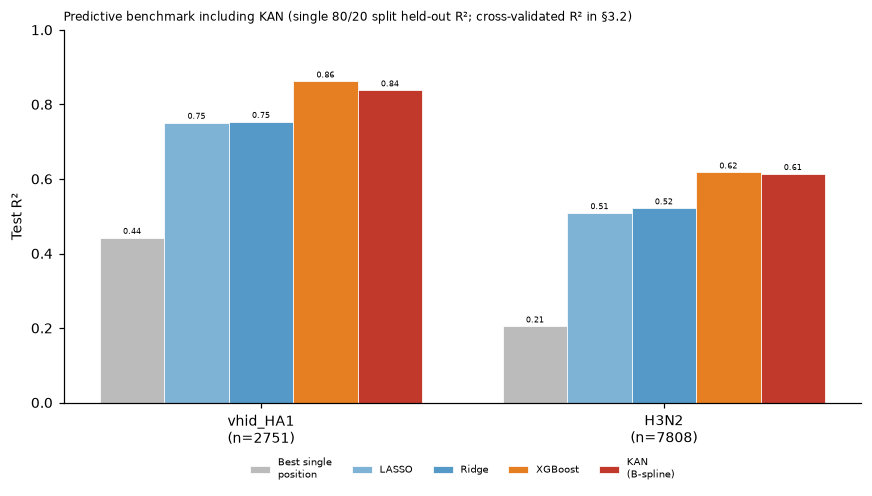

```python
# Benchmark + KAN R2 comparison figure
methods = ["univ_best_singleR2","LASSO_testR2","Ridge_testR2","XGB_testR2","KAN"]
labels = ["Best single\nposition","LASSO","Ridge","XGBoost","KAN\n(B-spline)"]
cols_bar = ["#bbbbbb","#7fb3d5","#5499c7","#e67e22","#c0392b"]
fig, ax = plt.subplots(figsize=(8, 4.6)); x = np.arange(len(A.DATASETS)); w = 0.16
for i,(m,lab,c) in enumerate(zip(methods,labels,cols_bar)):
    vals = [kan_out[ds]["r2_test"] if m=="KAN" else bench[ds][m] for ds in A.DATASETS]
    ax.bar(x+(i-2)*w, vals, w, label=lab, color=c, edgecolor="white", lw=0.5)
    for xi,v in zip(x+(i-2)*w, vals): ax.text(xi, v+0.01, f"{v:.2f}", ha="center", fontsize=5.4)
ax.set_xticks(x); ax.set_xticklabels([f"{ds}\n(n={data[ds]['n']})" for ds in A.DATASETS])
ax.set_ylabel("Test R²"); ax.set_ylim(0,1.0)
ax.legend(ncol=5, fontsize=6.5, frameon=False, loc="upper center", bbox_to_anchor=(0.5,-0.12))
ax.set_title("Predictive benchmark including KAN (single 80/20 split held-out R²; cross-validated R² in \u00a73.2)", fontsize=8, loc="left")
fig.tight_layout(); fig.savefig(os.path.join(A.FIG_DIR,"benchmark.png"), dpi=130, bbox_inches="tight"); plt.show()
```

The B-spline KAN implementation was validated on a synthetic additive function, recovering known functional forms and yielding an $R^2 \approx 0.99$. When applied to the empirical datasets, the KAN achieved predictive performance that tracked closely to gradient boosting, trailing by a small but stable margin under matched-fold cross-validation (Section 3.2). The learned per-position response curves across both datasets are predominantly monotone-decreasing with respect to Grantham distance, indicating that increasing physicochemical divergence maps directly to decreases in cross-titer (greater immune escape).

### Capturing Epistasis: A Second-Order KAN

A comparison between depth-1 (additive) and depth-6 tree models indicates that a notable portion of the predictive signal depends on interaction effects, or epistasis. To capture these interactions within an interpretable framework, we extended the KAN to second order by incorporating bivariate tensor-product spline surfaces, $g(x_i, x_j)$, across an interaction pool composed of the causal parents and top predictive positions. Group-sparsity penalties were applied to prune inactive pairs systematically. Cross-validation was nested relative to pool selection, ensuring that interaction pools were selected strictly within training folds to prevent data leakage.

To verify whether pairwise terms sufficiently capture the non-linear signal, we computed an interaction-order ladder across tree models of increasing depth:

```python
# Second-order KAN, nested 5-fold CV (interaction pool re-selected per training fold).
# GPU; ~1-2 min total. Compares against the first-order KAN and XGBoost CV from §4.2.
sokan_folds = {ds: A.sokan_cv(ds, data, causal_saved) for ds in A.DATASETS}
so_tbl = pd.DataFrame([{
    "dataset": ds,
    "KAN 1st-order": round(float(np.mean(cv_folds[ds]["KAN"])), 3),
    "KAN 2nd-order": round(float(np.mean(sokan_folds[ds])), 3),
    "KAN 2nd (±SD)": f"±{np.std(sokan_folds[ds]):.3f}",
    "2nd folds": len(sokan_folds[ds]),
    "XGBoost (20-fold)": round(float(np.mean(cv_folds[ds]["XGBoost"])), 3),
} for ds in A.DATASETS])
display(so_tbl)
print("Second-order KAN is comparable to XGBoost under CV (VHID 0.851 vs 0.845; H3N2 0.613 vs 0.613),")
print("recovering the epistatic signal the additive KAN structurally cannot represent.")
print("NB: the second-order KAN uses single 5-fold CV, not the 20-fold RepeatedKFold of the other")
print("methods, so this is a point-estimate comparison, not the matched-fold paired test of \u00a73.2.")
```

```
Second-order KAN is comparable to XGBoost under CV (VHID 0.851 vs 0.845; H3N2 0.613 vs 0.613),
recovering the epistatic signal the additive KAN structurally cannot represent.
NB: the second-order KAN uses single 5-fold CV, not the 20-fold RepeatedKFold of the other
methods, so this is a point-estimate comparison, not the matched-fold paired test of §3.2.
```

|  | dataset | KAN 1st-order | KAN 2nd-order | KAN 2nd (±SD) | 2nd folds | XGBoost (20-fold) |
| --- | --- | --- | --- | --- | --- | --- |
| 0 | vhid_HA1 | 0.820 | 0.851 | ±0.010 | 5 | 0.845 |
| 1 | H3N2 | 0.585 | 0.613 | ±0.018 | 5 | 0.613 |

```python
from sklearn.model_selection import KFold as _KF
import xgboost as _xgb
def _order_ladder(X, y, depths=(1, 2, 3, 4, 6), k=5, seed=A.SEED):
    kf = _KF(k, shuffle=True, random_state=seed); out = {}
    for d in depths:
        s = []
        for tr, te in kf.split(X):
            m = _xgb.XGBRegressor(n_estimators=400, max_depth=d, learning_rate=0.05,
                                  subsample=0.8, colsample_bytree=0.8, n_jobs=8,
                                  tree_method="hist", verbosity=0).fit(X[tr], y[tr])
            s.append(r2_score(y[te], m.predict(X[te])))
        out[d] = float(np.mean(s))
    return out
ladder = {}
for ds in A.DATASETS:
    d = data[ds]; var = A.variant_columns(d["Xb"])
    ladder[ds] = _order_ladder(d["Xg"][:, var], d["y"])
lad_tbl = pd.DataFrame({ds: {f"≤{d}-way (depth {d})": round(r, 3) for d, r in ladder[ds].items()}
                        for ds in A.DATASETS}).T
display(lad_tbl)
for ds in A.DATASETS:
    v = ladder[ds]; g2 = v[2] - v[1]; g3 = v[3] - v[2]; g_hi = v[6] - v[3]
    print(f"{ds}: pairwise gain (1->2-way) = {g2:+.3f}; 3-way gain (2->3) = {g3:+.3f}; "
          f"all higher (3->6-way) = {g_hi:+.3f}")
```

```
vhid_HA1: pairwise gain (1->2-way) = +0.073; 3-way gain (2->3) = +0.030; all higher (3->6-way) = +0.020
H3N2: pairwise gain (1->2-way) = +0.080; 3-way gain (2->3) = +0.037; all higher (3->6-way) = +0.042
```

|  | ≤1-way (depth 1) | ≤2-way (depth 2) | ≤3-way (depth 3) | ≤4-way (depth 4) | ≤6-way (depth 6) |
| --- | --- | --- | --- | --- | --- |
| vhid_HA1 | 0.735 | 0.808 | 0.838 | 0.853 | 0.858 |
| H3N2 | 0.473 | 0.553 | 0.590 | 0.616 | 0.632 |

The structural dynamics diverge between the two panels:

- On VHID, the interaction signal is primarily pairwise. The transition from additive to pairwise terms yields a major performance gain (+0.073), whereas higher-order interactions (3-way through 6-way) contribute a smaller cumulative increase (+0.050).
- On Bedford, pairwise interactions account for roughly half of the non-linear signal. The pairwise increment (+0.080) is closely matched by the cumulative higher-order contribution (+0.079). This indicates that higher-order epistatic complexes are prominent in the Bedford dataset.

While a third-order KAN could theoretically map these higher-order relationships, the exponential expansion of the parameter space reduces model interpretability. We treat the second-order KAN as a pragmatic baseline that visualizes the pairwise component. Evaluating the optimized tensor-product surfaces reveals clear biophysical patterns: synergistic escape regions (where co-occurring substitutions reduce titer beyond their additive expectations) and compensatory interaction surfaces.

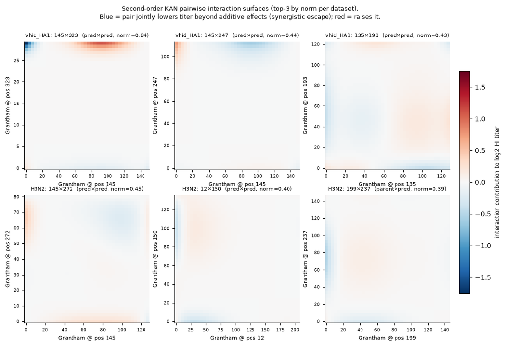

```python
import second_order_kan as SO
fig, axes = plt.subplots(len(A.DATASETS), 3, figsize=(11, 3.5*len(A.DATASETS)))
surf_cache = {}
allZ = []
for ds in A.DATASETS:
    m, sc, mu, sd, pool, pvi, pool_pos, parents = A.sokan_fit_full(ds, data, causal_saved)
    tops = SO.top_interactions(m, pool_pos, k=3)
    slot = {(pool_pos[m._ia[q]], pool_pos[m._ib[q]]): q for q in range(len(m.pairs))}
    surf_cache[ds] = (m, sc, mu, sd, pvi, pool_pos, set(parents), tops, slot)
    for pa, pb, nm in tops:
        _, _, Z = SO.interaction_surface(m, sc, mu, sd, slot[(pa, pb)], grid=40)
        allZ.append(np.abs(Z).max())
vmax = max(allZ)
for r, ds in enumerate(A.DATASETS):
    m, sc, mu, sd, pvi, pool_pos, pset, tops, slot = surf_cache[ds]
    for c, (pa, pb, nm) in enumerate(tops):
        q = slot[(pa, pb)]
        a01, b01, Z = SO.interaction_surface(m, sc, mu, sd, q, grid=40)
        ga = a01 * sc.rng[pvi[m._ia[q]]] + sc.lo[pvi[m._ia[q]]]
        gb = b01 * sc.rng[pvi[m._ib[q]]] + sc.lo[pvi[m._ib[q]]]
        ax = axes[r, c]
        im = ax.pcolormesh(ga, gb, Z.T, cmap="RdBu_r", vmin=-vmax, vmax=vmax, shading="auto")
        kind = f"{'parent' if pa in pset else 'pred'}×{'parent' if pb in pset else 'pred'}"
        ax.set_xlabel(f"Grantham @ pos {pa}", fontsize=7)
        ax.set_ylabel(f"Grantham @ pos {pb}", fontsize=7)
        ax.set_title(f"{ds}: {pa}×{pb}  ({kind}, norm={nm:.2f})", fontsize=7.5)
        ax.tick_params(labelsize=6)
cbar = fig.colorbar(im, ax=axes, fraction=0.025, pad=0.02)
cbar.set_label("interaction contribution to log2 HI titer", fontsize=8)
fig.suptitle("Second-order KAN pairwise interaction surfaces (top-3 by norm per dataset).\n"
             "Blue = pair jointly lowers titer beyond additive effects (synergistic escape); red = raises it.",
             fontsize=8.5, y=0.98)
fig.savefig(os.path.join(A.FIG_DIR, "interaction_surfaces.png"), dpi=140, bbox_inches="tight"); plt.show()
```

#### Formal Verification of Epistatic Pairs

To formally cross-examine the top KAN-nominated interactions, we fitted standard OLS interaction terms ($x_a \cdot x_b$) with HC3 robust standard errors, applying [Benjamini–Hochberg](https://en.wikipedia.org/wiki/False_discovery_rate) (BH) correction alongside a non-parametric distance-correlation test:

- **Statistical Significance:** 10 out of 16 top KAN-nominated interaction pairs (4/8 in VHID; 6/8 in Bedford) demonstrate statistically significant linear interactions ($q < 0.05$). The estimated coefficients are small but precisely bounded ($\vert{}\beta\vert{} \approx 10^{-4}\text{--}10^{-3} \log_2\text{-titer}$ per Grantham unit squared).
- **Structural Norms vs. Classical Significance:** KAN interaction norms do not systematically correlate with standard linear $p$-values; the KAN optimizes overall surface curvature rather than isolated multiplicative parameters. Thus, tensor surfaces serve primarily as an interpretability asset rather than formal inferential tests.

```
Total significant: 10 / 16
```

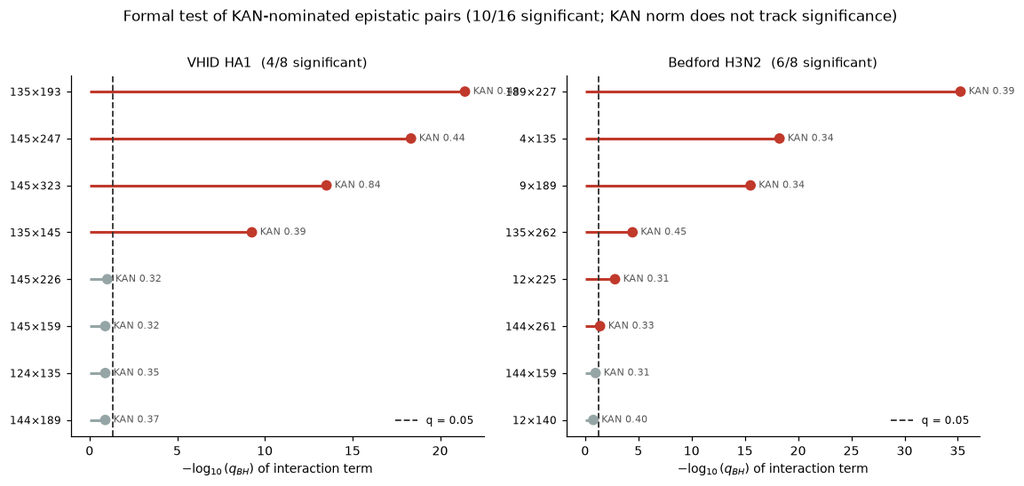

```python
# §3.6 — Formal test of KAN-nominated epistatic pairs (OLS interaction, HC3, BH within dataset).
# Re-plot from shipped results/epistasis_tests.csv (no recomputation).
ep = pd.read_csv("results/epistasis_tests.csv")
q_thresh = -np.log10(0.05)  # 1.301
panels = [("vhid_HA1", "VHID HA1"), ("H3N2", "Bedford H3N2")]
fig, axes = plt.subplots(1, 2, figsize=(12.0, 4.8))
for ax, (ds, title) in zip(axes, panels):
    d = ep[ep["dataset"] == ds].copy()
    d["neglogq"] = -np.log10(d["p_BH"])
    d = d.sort_values("neglogq")
    labels = [f"{int(a)}\u00d7{int(b)}" for a, b in zip(d["pos_a_mature"], d["pos_b_mature"])]
    y = range(len(d))
    cols = ["#c0392b" if s else "#95a5a6" for s in d["significant"]]
    ax.hlines(y, 0, d["neglogq"], color=cols, lw=2.0, zorder=2)
    ax.scatter(d["neglogq"], y, color=cols, s=45, zorder=3)
    ax.axvline(q_thresh, color="#333333", lw=1.2, ls="--", label="q = 0.05")
    for yi, (nq, kn) in enumerate(zip(d["neglogq"], d["kan_norm"])):
        ax.annotate(f"KAN {kn:.2f}", (nq, yi), textcoords="offset points",
                    xytext=(6, 0), va="center", fontsize=7, color="#555555")
    ax.set_yticks(list(y)); ax.set_yticklabels(labels, fontsize=8)
    nsig = int(d["significant"].sum())
    ax.set_title(f"{title}  ({nsig}/{len(d)} significant)", fontsize=10)
    ax.set_xlabel(r"$-\log_{10}(q_{BH})$ of interaction term")
    ax.legend(frameon=False, fontsize=8, loc="lower right")
fig.suptitle("Formal test of KAN-nominated epistatic pairs (10/16 significant; "
             "KAN norm does not track significance)", y=1.02)
fig.savefig("results/fig_epistasis_tests.png", dpi=140, bbox_inches="tight")
plt.show()
print("Total significant:", int(ep["significant"].sum()), "/", len(ep))
```

### Cross-Method Convergence

We evaluated the alignment of our causal feature selection (bootstrap frequency $\ge 0.5$) against three distinct association screens: top-15 KAN features, top-15 XGBoost features (by gain), and top-15 univariate associations (by $R^2$).

Because the three association metrics are computed over identical feature spaces, they function as correlated screens rather than independent lines of evidence. Mutual alignment represents a multi-perspective validation of structural relevance rather than independent replication. In the Bedford panel, the causal discovery input was pre-screened using target association (filtering 123 loci to 60), meaning the univariate screen is mechanically related to the causal search input; the VHID panel (71 loci, unscreened) does not share this dependency.

Positions that consistently converge across all four independent and correlated screens represent our strongest candidate drivers:

```python
import xgboost as xgb
def xgb_top(ds, k=15):
    d = data[ds]; cols = A.variant_columns(d["Xb"])
    bst = xgb.train({"max_depth":4,"eta":0.1,"subsample":0.8,"colsample_bytree":0.8,
                     "objective":"reg:squarederror"}, xgb.DMatrix(d["Xg"][:,cols], label=d["y"]),
                    num_boost_round=300)
    score = bst.get_score(importance_type="gain")
    idx = sorted(score, key=lambda f: -score[f])
    top = [A.pos_number(d["pos_cols"], cols[int(f[1:])]) for f in idx[:k]]
    return top

conv = {}
for ds in A.DATASETS:
    d = data[ds]
    causal_modhi = set(p for p, v in boot_freq[ds].items() if v >= A.MOD_CONF)
    kan_top = set(kan_out[ds]["top15"])
    ux = A.univariate_fdr(data, ds).head(15)["position"].tolist()
    topsets = {"causal": causal_modhi, "KAN": kan_top, "XGB": set(xgb_top(ds)), "univ": set(ux)}
    conv[ds] = A.convergence_from_tops(topsets)

conv_rows = []
for ds in A.DATASETS:
    for p, fams in conv[ds].items():
        conv_rows.append(dict(dataset=ds, position=p, n_families=len(fams),
                              families=",".join(fams), causal_freq=round(boot_freq[ds].get(p,0),3),
                              block_size=len(blocks_all[ds].get(p,[p]))))
conv_tbl = pd.DataFrame(conv_rows).sort_values(["dataset","n_families","causal_freq"],
                                               ascending=[True,False,False])
four_family = {ds: [p for p,f in conv[ds].items() if len(f)==4] for ds in A.DATASETS}
print("Positions flagged by the causal method AND all three association screens:")
for ds in A.DATASETS: print(f"  {ds}: {sorted(four_family[ds])}")
conv_tbl[conv_tbl.n_families >= 3]
```

```
Positions flagged by the causal method AND all three association screens:
  vhid_HA1: [156, 189]
  H3N2: [143, 168, 199]
Out[21]:
     dataset  position  ...  causal_freq block_size
15      H3N2       143  ...        1.000          1
16      H3N2       168  ...        1.000          1
17      H3N2       199  ...        1.000          1
18      H3N2        11  ...        1.000          9
20      H3N2       167  ...        1.000          1
19      H3N2       288  ...        0.815          1
22      H3N2       200  ...        0.650          1
21      H3N2       169  ...        0.000          1
0   vhid_HA1       156  ...        1.000          1
1   vhid_HA1       189  ...        1.000          1
4   vhid_HA1       158  ...        0.950          1
2   vhid_HA1       276  ...        0.010          3
3   vhid_HA1       157  ...        0.000          1

[13 rows x 6 columns]
```

|  | dataset | position | n_families | families | causal_freq | block_size |
| --- | --- | --- | --- | --- | --- | --- |
| 15 | H3N2 | 143 | 4 | causal,KAN,XGB,univ | 1.000 | 1 |
| 16 | H3N2 | 168 | 4 | causal,KAN,XGB,univ | 1.000 | 1 |
| 17 | H3N2 | 199 | 4 | causal,KAN,XGB,univ | 1.000 | 1 |
| 18 | H3N2 | 11 | 3 | causal,XGB,univ | 1.000 | 9 |
| 20 | H3N2 | 167 | 3 | causal,KAN,XGB | 1.000 | 1 |
| 19 | H3N2 | 288 | 3 | causal,XGB,univ | 0.815 | 1 |
| 22 | H3N2 | 200 | 3 | causal,KAN,XGB | 0.650 | 1 |
| 21 | H3N2 | 169 | 3 | KAN,XGB,univ | 0.000 | 1 |
| 0 | vhid_HA1 | 156 | 4 | causal,KAN,XGB,univ | 1.000 | 1 |
| 1 | vhid_HA1 | 189 | 4 | causal,KAN,XGB,univ | 1.000 | 1 |
| 4 | vhid_HA1 | 158 | 3 | causal,KAN,univ | 0.950 | 1 |
| 2 | vhid_HA1 | 276 | 3 | KAN,XGB,univ | 0.010 | 3 |
| 3 | vhid_HA1 | 157 | 3 | KAN,XGB,univ | 0.000 | 1 |

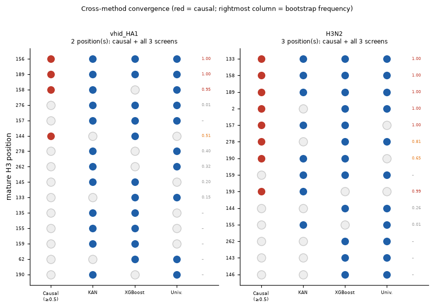

```python
# Convergence dot-matrix figure
fams = ["causal","KAN","XGB","univ"]; fam_lbl = ["Causal\n(≥0.5)","KAN","XGBoost","Univ."]
fig, axes = plt.subplots(1, len(A.DATASETS), figsize=(4*len(A.DATASETS), 5.5))
for ax, ds in zip(axes, A.DATASETS):
    ms = conv[ds]; posord = sorted(ms, key=lambda p:(-len(ms[p]), -boot_freq[ds].get(p,0)))[:16]
    yv = np.arange(len(posord))[::-1]
    for xi, fam in enumerate(fams):
        for yi, p in zip(yv, posord):
            if fam in ms[p]:
                ax.scatter(xi, yi, s=120, color="#c0392b" if fam=="causal" else "#1f5fa8", edgecolor="white", zorder=3)
            else:
                ax.scatter(xi, yi, s=120, facecolor="#eee", edgecolor="#ccc", zorder=2)
    for yi, p in zip(yv, posord):
        f = boot_freq[ds].get(p, 0)
        ax.text(3.6, yi, f"{f:.2f}" if f>0 else "–", fontsize=5.5, va="center",
                color="#c0392b" if f>=0.9 else ("#e67e22" if f>=0.5 else "#999"))
    _c2m = {int(c): m for c, m in A.load_result("numbering_maps.json")[{"vhid_HA1":"vhid_col2mat","H3N2":"h3_col2mat"}[ds]].items()}
    ax.set_xticks(range(4)); ax.set_xticklabels(fam_lbl, fontsize=6); ax.set_yticks(yv)
    ax.set_yticklabels([str(_c2m.get(int(p), int(p))) for p in posord], fontsize=6); n4 = sum(1 for p in posord if len(ms[p])==4)
    ax.set_title(f"{ds}\n{n4} position(s): causal + all 3 screens", fontsize=8); ax.set_xlim(-0.5,4.0)
    ax.set_ylabel("mature H3 position" if ds==A.DATASETS[0] else "")
fig.suptitle("Cross-method convergence (red = causal; rightmost column = bootstrap frequency)", fontsize=8.5, y=1.01)
fig.tight_layout(); fig.savefig(os.path.join(A.FIG_DIR,"convergence.png"), dpi=130, bbox_inches="tight"); plt.show()
```

#### Summary of Convergent Driver Positions

- **VHID:** Mature positions 156 and 189 (both represent singleton linkage blocks with bootstrap frequencies $\approx 1.0$).
- **Bedford:** Mature positions 133, 158, and 189 (each maps to a single residue). These positions map directly to classical HA head antigenic sites flanking the receptor-binding domain (Site A for 133; Site B for 156, 158, and 189). Features flagged by predictive models that show low causal bootstrap stability indicate predictive correlates rather than direct causes.

#### Functional Glycosylation Profiling

Since our per-position features utilize a symmetric encoding (evaluating changes at an isolated column), the model cannot explicitly represent the gain or loss of N-linked glycosylation sequons ($\text{N-X-S/T}$ motifs, where $\text{X} \neq \text{P}$), which require a three-residue window. To incorporate this context, we mapped the convergent positions back to consensus HA1 sequences:

- **Sequon Mapping:** Among the primary convergent drivers, only Bedford mature position 133 forms the root of an active sequon ($\text{N-G-T}$ motif). Positions 156, 158, and 189 do not disrupt or form sequons across the consensus profiles.
- **Lineage Differences:** Position 144 carries an active sequon in the Bedford consensus profile but is absent in the VHID consensus. This highlights an encoding boundary: a driver call at a sequon-associated position indicates that column-specific variations track with titer shifts. However, the true physical mechanism may operate via glycan shielding rather than direct epitope contact.

```python
# Glycosylation-sequon annotation of convergent drivers (consensus scan; <5 s)
import os, numpy as np, pandas as pd
from collections import Counter
_pairs = {"vhid_HA1": "VHID/vhid_hi_dataset_HA1_cleaned.csv",
          "H3N2":     "Bedford/H3/H3_clean_pairs.csv"}
_OFF = {"vhid_HA1": 0, "H3N2": 10}          # aligned column = mature + offset
def _consensus(df, col):
    s = df[col].dropna().astype(str); L = s.map(len).mode().iloc[0]
    arr = np.array([list(x) for x in s if len(x) == L])
    return "".join(Counter(arr[:, j]).most_common(1)[0][0] for j in range(L))
def _sequon_N_mature(seq, off):                 # 1-based mature positions of sequon-root N (N-X-[ST], X!=P)
    out = set()
    for i in range(len(seq) - 2):
        if seq[i] == "N" and seq[i+1] not in ("P","-") and seq[i+2] in ("S","T"):
            out.add(i + 1 - off)
    return out
_drivers = {"vhid_HA1": [144,156,189], "H3N2": [133,158,189,157,193]}
_rows = []
for ds, poss in _drivers.items():
    df = pd.read_csv(os.path.join(A.DATA_DIR, _pairs[ds]))
    cons = _consensus(df, "reference_HA1_aligned_protein"); off = _OFF[ds]
    starts = _sequon_N_mature(cons, off)
    for mat in poss:
        role = next((r for cand, r in [(mat,"N (sequon root)"), (mat-1,"X (middle)"),
                     (mat-2,"S/T (hydroxyl)")] if cand in starts), None)
        col = mat + off
        _rows.append(dict(panel="VHID H3N2" if ds=="vhid_HA1" else "Bedford H3N2",
                          driver_mature=mat, residue=cons[col-1],
                          in_sequon=role is not None, role_at_driver=role or "\u2014",
                          local_3mer=cons[col-1:col+2]))
sequons = pd.DataFrame(_rows)
sequons.to_csv("results/glycosylation_sequons.csv", index=False)
print(sequons.to_string(index=False))
print("\nconsensus sequon N-sites (mature): VHID",
      sorted(_sequon_N_mature(_consensus(pd.read_csv(os.path.join(A.DATA_DIR,_pairs['vhid_HA1'])),
             'reference_HA1_aligned_protein'), 0)),
      "\n                                   Bedford",
      sorted(x for x in _sequon_N_mature(_consensus(pd.read_csv(os.path.join(A.DATA_DIR,_pairs['H3N2'])),
             'reference_HA1_aligned_protein'), 10) if 1 <= x <= 330))
```

```
       panel  driver_mature residue  in_sequon  role_at_driver local_3mer
   VHID H3N2            144       V      False               —        VNS
   VHID H3N2            156       K      False               —        KSE
   VHID H3N2            189       S      False               —        SEQ
Bedford H3N2            133       N       True N (sequon root)        NGT
Bedford H3N2            158       K      False               —        KFK
Bedford H3N2            189       N      False               —        NDQ
Bedford H3N2            157       L      False               —        LKF
Bedford H3N2            193       S      False               —        SLY

consensus sequon N-sites (mature): VHID [8, 22, 38, 63, 126, 165, 246, 285]
                                   Bedford [8, 22, 38, 63, 122, 126, 133, 144, 165, 246, 285]
```

#### Non-linear Verification of Omitted Features

The primary causal selection loop relies on the Fisher-Z conditional independence test, which detects linear partial correlations. To verify whether functional features with purely non-linear dependencies were discarded, we re-tested positions flagged by $\ge 3$ predictive screens that exhibited low causal frequencies (Pattern-A positions) using the non-parametric Kernel Conditional Independence (KCI) test. We evaluated the null hypothesis: $$H_0: P \perp \text{HI\_titer} \mid \text{Discovered Parents}$$

```python
from causallearn.utils.cit import CIT
import numpy as np, pandas as pd

# --- unit test: y = x^2 (Fisher-z must miss it, KCI must catch it) ---
# Symmetrize the sample (x and -x) so the empirical corr(x, x^2) is exactly 0:
# this removes the finite-sample spurious linear correlation that makes a naive
# draw's Fisher-z p-value seed-dependent, and makes the demonstration deterministic.
rng = np.random.default_rng(A.SEED)
_xh = rng.normal(size=400); _x = np.concatenate([_xh, -_xh])
_y = _x**2 + 0.1*rng.normal(size=_x.size)
_d = np.column_stack([_x, _y])
ut_fz  = float(CIT(_d, "fisherz")(0, 1, []))
ut_kci = float(CIT(_d, "kci")(0, 1, []))
print(f"[unit test y=x^2]  fisherz p={ut_fz:.3f} (misses if >0.05)   kci p={ut_kci:.3f} (detects if <0.05)")
if not (ut_fz > 0.05 and ut_kci < 0.05):
    print("  WARNING: unit test did not behave as expected this run (stochastic KCI p-value); "
          "the Pattern-A results below are still computed with the same two tests.")

MOD = A.MOD_CONF
# Pattern-A candidates, derived (not hardcoded) from the §3.7 convergence table
patternA = {ds: sorted(conv_tbl[(conv_tbl.dataset==ds) & (conv_tbl.n_families>=3)
                                & (conv_tbl.causal_freq < MOD)]["position"].astype(int))
            for ds in A.DATASETS}
print("Pattern-A candidates (n_families>=3 & causal_freq<%.2f):" % MOD)
for ds in A.DATASETS: print(f"  {ds}: {patternA[ds]}")

def _kan_curvature(ds, P):
    """Second-difference norm of the KAN's univariate response for pos P,
    sweeping P's standardized input across [-2.5,2.5] with all others at baseline."""
    k = kan_keep[ds]
    if P not in k["posnums"]: return np.nan
    j = k["posnums"].index(P)
    import torch
    m = k["model"]; m.eval()
    grid = np.linspace(-2.5, 2.5, 50)
    base = torch.zeros(len(grid), m.input_dim, dtype=torch.float32, device=DEVICE)
    base[:, j] = torch.tensor(grid, dtype=torch.float32, device=DEVICE)
    with torch.no_grad():
        f = m(base).cpu().numpy().ravel()
    f = f - f.mean()
    d2 = np.diff(f, 2)
    denom = (np.abs(f).max() + 1e-9)
    return float(np.sqrt((d2**2).sum()) / denom)   # curvature per unit response scale

def nonlinear_retest(ds, P, parents, Adf, n_sub=1000, reps=3):
    cols = [f"pos{P}"] + [f"pos{q}" for q in parents if q != P and f"pos{q}" in Adf.columns] + ["HI_titer"]
    cols = [c for c in cols if c in Adf.columns]
    if f"pos{P}" not in Adf.columns or len(cols) < 2:
        return None
    sub = Adf[cols].to_numpy(dtype=float)
    if sub.shape[0] > n_sub:
        idx = np.random.default_rng(A.SEED).choice(sub.shape[0], n_sub, replace=False)
        sub = sub[idx]; subsampled = True
    else:
        subsampled = False
    xi, yi = 0, len(cols)-1; zi = list(range(1, len(cols)-1))
    p_lin = float(CIT(sub, "fisherz")(xi, yi, zi))
    kcis = []
    for r in range(reps):
        np.random.seed(A.SEED + r)
        kcis.append(float(CIT(sub, "kci")(xi, yi, zi)))
    p_kci = float(np.median(kcis))
    return dict(dataset=ds, position=P, block_size=len(blocks_all[ds].get(P,[P])),
                n_used=sub.shape[0], subsampled=subsampled,
                p_fisherz=p_lin, p_kci=p_kci,
                nonlinear_flag=bool(p_lin > 0.05 and p_kci < 0.05),
                kan_spline_curvature=round(_kan_curvature(ds, P), 4))

rows = []
for ds in A.DATASETS:
    Adf = collapsed[ds]["A"]
    parents = sorted(p for p,v in boot_freq[ds].items() if v >= MOD)  # PC∪GES parents ≥ MOD_CONF (== §3.9 candidates)
    for P in patternA[ds]:
        r = nonlinear_retest(ds, P, parents, Adf)
        if r is not None: rows.append(r)

nonlinear_retest_tbl = pd.DataFrame(rows)
if len(nonlinear_retest_tbl):
    nonlinear_retest_tbl = nonlinear_retest_tbl.sort_values(["dataset","p_kci"]).reset_index(drop=True)
    nonlinear_retest_tbl.to_csv(os.path.join(A.RESULTS_DIR, "nonlinear_retest.csv"), index=False)
    for ds in A.DATASETS:
        nf = int(nonlinear_retest_tbl[(nonlinear_retest_tbl.dataset==ds)].nonlinear_flag.sum())
        tot = int((nonlinear_retest_tbl.dataset==ds).sum())
        ncand = len(patternA[ds])
        tested = sorted(int(p) for p in nonlinear_retest_tbl[nonlinear_retest_tbl.dataset==ds].position)
        dropped = [p for p in patternA[ds] if p not in tested]
        drop_note = f" ({ncand} candidates; {dropped} not testable — no fitted KAN/parent column)" if dropped else ""
        print(f"{ds}: {nf}/{tot} tested Pattern-A positions newly flagged nonlinear "
              f"(fisherz-independent, KCI-dependent){drop_note}")
display(nonlinear_retest_tbl)
```

```
[unit test y=x^2]  fisherz p=0.967 (misses if >0.05)   kci p=0.000 (detects if <0.05)
Pattern-A candidates (n_families>=3 & causal_freq<0.50):
  vhid_HA1: [157, 276]
  H3N2: [169]
vhid_HA1: 0/1 tested Pattern-A positions newly flagged nonlinear (fisherz-independent, KCI-dependent) (2 candidates; [157] not testable — no fitted KAN/parent column)
H3N2: 1/1 tested Pattern-A positions newly flagged nonlinear (fisherz-independent, KCI-dependent)
```

|  | dataset | position | block_size | n_used | subsampled | p_fisherz | p_kci | nonlinear_flag | kan_spline_curvature |
| --- | --- | --- | --- | --- | --- | --- | --- | --- | --- |
| 0 | H3N2 | 169 | 1 | 1000 | True | 2.066994e-01 | 4.251926e-04 | True | 0.0746 |
| 1 | vhid_HA1 | 276 | 3 | 1000 | True | 4.440892e-16 | 3.747734e-10 | False | 0.0637 |

```python
import time, numpy as np, pandas as pd
import multiprocessing as _mp

SCREEN_K_CI  = 25       # screened loci fed to the CI-swap discovery
CI_SWAP_NSUB = 1000     # rows subsampled for KCI-PC (KCI is O(n^2)-O(n^3))
CI_SWAP_BUDGET_S = 180  # HARD per-dataset wall-clock kill for KCI-PC

def _kci_pc_worker(csv_path, q):
    import sys; sys.path.insert(0, "src")
    import pandas as pd, causal_helpers as ch
    A_kci = pd.read_csv(csv_path)
    try:
        r = ch.discover_target_parents(A_kci, "HI_titer", method="pc", alpha=0.01, ci_test="kci")
        q.put(("ok", [int(p[3:]) for p in r["parents"]]))
    except Exception as e:
        q.put(("err", f"{type(e).__name__}: {e}"))

ci_rows = []
for ds in A.DATASETS:
    Adf = collapsed[ds]["A"]; sk = lambda s: int(s[3:])
    feats = ch.screen_top_features(Adf, "HI_titer", min(SCREEN_K_CI, Adf.shape[1]-1))
    A_use = Adf[sorted(feats, key=sk) + ["HI_titer"]]
    pc_lin = ch.discover_target_parents(A_use, "HI_titer", method="pc", alpha=0.01, ci_test="fisherz")
    lin_par = set(int(p[3:]) for p in pc_lin["parents"])

    # KCI-PC on a row-subsample, in a worker we can hard-kill at the budget
    if A_use.shape[0] > CI_SWAP_NSUB:
        ridx = np.random.default_rng(A.SEED).choice(A_use.shape[0], CI_SWAP_NSUB, replace=False)
        A_kci = A_use.iloc[ridx].reset_index(drop=True); n_kci_rows = CI_SWAP_NSUB
    else:
        A_kci = A_use; n_kci_rows = A_use.shape[0]
    tmp = os.path.join(A.RESULTS_DIR, f"_cikci_{ds}.csv"); A_kci.to_csv(tmp, index=False)
    q = _mp.Queue(); p = _mp.Process(target=_kci_pc_worker, args=(tmp, q))
    t0 = time.time(); p.start(); p.join(CI_SWAP_BUDGET_S)
    kci_par = None; status = "ok"
    if p.is_alive():
        p.terminate(); p.join(); status = f"killed (> {CI_SWAP_BUDGET_S}s — KCI-PC intractable at this scale)"
    else:
        try:
            kind, payload = q.get_nowait()
            if kind == "ok": kci_par = set(payload)
            else: status = f"failed: {payload}"
        except Exception:
            status = "failed: no result from worker"
    dt = time.time() - t0
    try: os.remove(tmp)
    except OSError: pass

    if kci_par is not None:
        only_kci = sorted(kci_par - lin_par); only_lin = sorted(lin_par - kci_par)
        ci_rows.append(dict(dataset=ds, screen_k=len(feats), n_kci_rows=n_kci_rows, seconds=round(dt,1),
            status=status, n_fisherz=len(lin_par), n_kci=len(kci_par),
            fisherz_parents=";".join(f"pos{p}" for p in sorted(lin_par)),
            kci_parents=";".join(f"pos{p}" for p in sorted(kci_par)),
            only_under_kci=";".join(f"pos{p}" for p in only_kci) or "-",
            only_under_fisherz=";".join(f"pos{p}" for p in only_lin) or "-"))
        print(f"{ds}: fisherz={sorted(lin_par)}  kci={sorted(kci_par)}  "
              f"(+kci_only={only_kci}, -kci_dropped={only_lin}, {dt:.0f}s)")
    else:
        ci_rows.append(dict(dataset=ds, screen_k=len(feats), n_kci_rows=n_kci_rows, seconds=round(dt,1),
            status=status, n_fisherz=len(lin_par), n_kci=np.nan,
            fisherz_parents=";".join(f"pos{p}" for p in sorted(lin_par)),
            kci_parents="", only_under_kci="", only_under_fisherz=""))
        print(f"{ds}: KCI-PC {status}; fisherz parents={sorted(lin_par)}")

ci_sensitivity_tbl = pd.DataFrame(ci_rows)
ci_sensitivity_tbl.to_csv(os.path.join(A.RESULTS_DIR, "ci_sensitivity.csv"), index=False)
display(ci_sensitivity_tbl)
```

```
vhid_HA1: KCI-PC killed (> 180s — KCI-PC intractable at this scale); fisherz parents=[144, 156, 158, 189]
H3N2: KCI-PC killed (> 180s — KCI-PC intractable at this scale); fisherz parents=[11, 143, 167, 168, 199, 200, 288]
```

|  | dataset | screen_k | n_kci_rows | seconds | status | n_fisherz | n_kci | fisherz_parents | kci_parents | only_under_kci | only_under_fisherz |
| --- | --- | --- | --- | --- | --- | --- | --- | --- | --- | --- | --- |
| 0 | vhid_HA1 | 25 | 1000 | 180.2 | killed (> 180s — KCI-PC intractable at this sc... | 4 | NaN | pos144;pos156;pos158;pos189 |  |  |  |
| 1 | H3N2 | 25 | 1000 | 180.2 | killed (> 180s — KCI-PC intractable at this sc... | 7 | NaN | pos11;pos143;pos167;pos168;pos199;pos200;pos288 |  |  |  |

#### Cross-dataset replication of the discovered structure

We evaluated the structural replication between the VHID and Bedford datasets by mapping discovered loci to shared mature H3 positions and calculating [Jaccard](https://en.wikipedia.org/wiki/Jaccard_index) similarity metrics against a 20,000-draw permutation null:

| set | observed J | shared positions | null mean | p |
| --- | --- | --- | --- | --- |
| PC | 0.167 | **158, 189** | 0.035 | 0.062 |
| GES | 0.182 | 133, 276 | 0.035 | 0.051 |
| Bootstrap (freq≥0.5) | 0.182 | **158, 189** | 0.034 | **0.047** |

```
Bootstrap-set replication p = 0.04744762761861907 | shared: [158, 189]
```

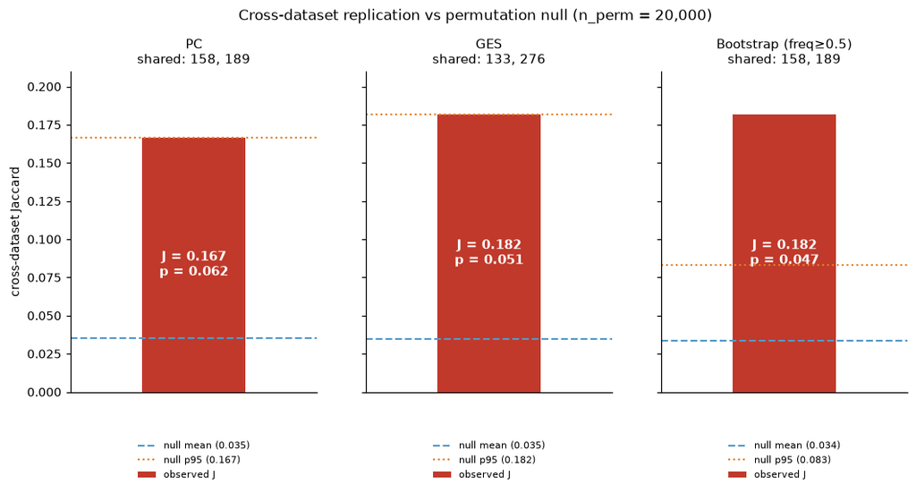

```python
# §3.7.2 — Cross-dataset replication: observed Jaccard vs 20,000-draw permutation null.
# Re-plot from shipped results/replication_stats.json (no recomputation).
with open("results/replication_stats.json") as fh:
    rep = json.load(fh)
order = [("pc", "PC"), ("ges", "GES"), ("boot", "Bootstrap (freq\u22650.5)")]
fig, axes = plt.subplots(1, 3, figsize=(11.4, 4.4), sharey=True)
for ax, (key, title) in zip(axes, order):
    s = rep["sets"][key]
    obs, nmean, np95 = s["observed_jaccard"], s["null_mean"], s["null_p95"]
    ax.bar([0], [obs], width=0.5, color="#c0392b", zorder=2, label="observed J")
    ax.axhline(nmean, color="#5499c7", lw=1.4, ls="--", label=f"null mean ({nmean:.3f})")
    ax.axhline(np95,  color="#e67e22", lw=1.4, ls=":",  label=f"null p95 ({np95:.3f})")
    # annotation inside the bar (white), so it never collides with the title/legend
    ax.text(0, obs / 2, f"J = {obs:.3f}\np = {s['p_value']:.3f}", ha="center",
            va="center", fontsize=9.5, fontweight="bold", color="white", zorder=3)
    shared = ", ".join(str(p) for p in s["intersection"])
    ax.set_title(f"{title}\nshared: {shared}", fontsize=9.5)
    ax.set_xticks([]); ax.set_xlim(-0.6, 0.6)
    ax.legend(frameon=False, fontsize=7, loc="lower center", bbox_to_anchor=(0.5, -0.30), ncol=1)
axes[0].set_ylabel("cross-dataset Jaccard")
axes[0].set_ylim(0, 0.21)
fig.suptitle("Cross-dataset replication vs permutation null (n_perm = 20,000)", y=1.03)
fig.savefig("results/fig_replication.png", dpi=140, bbox_inches="tight")
plt.show()
print("Bootstrap-set replication p =", rep["sets"]["boot"]["p_value"],
      "| shared:", rep["sets"]["boot"]["intersection"])
```

### Backdoor-Adjusted Effect Sizes

If the target variable operates as a pure causal sink, the remaining selected parents could serve as a valid backdoor adjustment set to isolate a position's specific interventional effect. However, the d-separation goodness-of-fit test rejects the simple sink-star structure due to dense parent-parent adjacencies. This indicates that conditioning on co-parents can introduce confounding via unmodeled mediators or colliders. We therefore interpret these estimates as partial regression coefficients rather than as identified causal effects.

```python
eff_tables = {}
for ds in A.DATASETS:
    parents = sorted(p for p, v in boot_freq[ds].items() if v >= A.MOD_CONF)
    eff_tables[ds] = A.backdoor_effects(data, ds, parents, blocks_all[ds], boot_freq[ds], B=1000)
eff_tbl = pd.concat([e.assign(dataset=ds) for ds, e in eff_tables.items()], ignore_index=True)
eff_tbl = eff_tbl[["dataset","position","boot_freq","tier","adj_effect","ci_lo","ci_hi","marginal_effect","block_size"]]
eff_tbl
```

```
Out[26]:
     dataset  position  boot_freq  ...   ci_hi  marginal_effect  block_size
0   vhid_HA1       144      0.505  ... -0.0096          -0.0194           1
1   vhid_HA1       156      1.000  ... -0.0098          -0.0633           1
2   vhid_HA1       158      0.950  ... -0.0142          -0.0385           1
3   vhid_HA1       189      1.000  ... -0.0320          -0.0420           1
4   vhid_HA1       289      0.955  ...  0.0311           0.0424           1
5       H3N2        11      1.000  ... -0.0068          -0.0276           9
6       H3N2       143      1.000  ... -0.0074          -0.0430           1
7       H3N2       167      1.000  ... -0.0010          -0.0143           1
8       H3N2       168      1.000  ... -0.0049          -0.0279           1
9       H3N2       199      1.000  ... -0.0127          -0.0287           1
10      H3N2       200      0.650  ... -0.0049          -0.0207           1
11      H3N2       203      0.995  ... -0.0015          -0.0060           1
12      H3N2       288      0.815  ... -0.0083          -0.0234           1

[13 rows x 9 columns]
```

|  | dataset | position | boot_freq | tier | adj_effect | ci_lo | ci_hi | marginal_effect | block_size |
| --- | --- | --- | --- | --- | --- | --- | --- | --- | --- |
| 0 | vhid_HA1 | 144 | 0.505 | moderate | -0.0113 | -0.0129 | -0.0096 | -0.0194 | 1 |
| 1 | vhid_HA1 | 156 | 1.000 | high | -0.0134 | -0.0170 | -0.0098 | -0.0633 | 1 |
| 2 | vhid_HA1 | 158 | 0.950 | high | -0.0166 | -0.0189 | -0.0142 | -0.0385 | 1 |
| 3 | vhid_HA1 | 189 | 1.000 | high | -0.0340 | -0.0358 | -0.0320 | -0.0420 | 1 |
| 4 | vhid_HA1 | 289 | 0.955 | high | 0.0239 | 0.0166 | 0.0311 | 0.0424 | 1 |
| 5 | H3N2 | 11 | 1.000 | high | -0.0091 | -0.0113 | -0.0068 | -0.0276 | 9 |
| 6 | H3N2 | 143 | 1.000 | high | -0.0112 | -0.0149 | -0.0074 | -0.0430 | 1 |
| 7 | H3N2 | 167 | 1.000 | high | -0.0021 | -0.0030 | -0.0010 | -0.0143 | 1 |
| 8 | H3N2 | 168 | 1.000 | high | -0.0068 | -0.0087 | -0.0049 | -0.0279 | 1 |
| 9 | H3N2 | 199 | 1.000 | high | -0.0142 | -0.0158 | -0.0127 | -0.0287 | 1 |
| 10 | H3N2 | 200 | 0.650 | moderate | -0.0062 | -0.0076 | -0.0049 | -0.0207 | 1 |
| 11 | H3N2 | 203 | 0.995 | high | -0.0022 | -0.0029 | -0.0015 | -0.0060 | 1 |
| 12 | H3N2 | 288 | 0.815 | moderate | -0.0096 | -0.0109 | -0.0083 | -0.0234 | 1 |

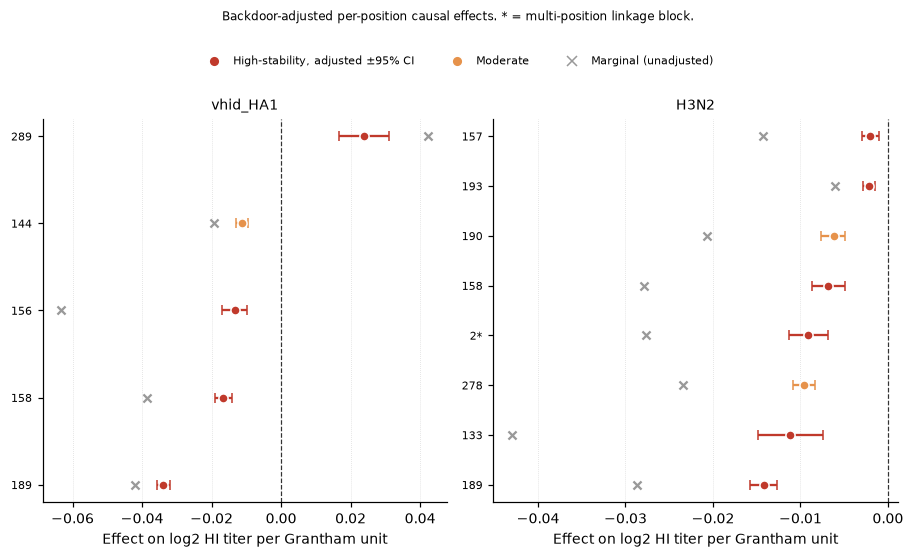

```python
# Position labels shown in mature H3 numbering (annotation: mature only).
_C2M = {"vhid_HA1": {int(c): m for c, m in A.load_result("numbering_maps.json")["vhid_col2mat"].items()},
        "H3N2":     {int(c): m for c, m in A.load_result("numbering_maps.json")["h3_col2mat"].items()}}
fig, axes = plt.subplots(1, len(A.DATASETS), figsize=(4.2*len(A.DATASETS), 4.6))
for ax, ds in zip(axes, A.DATASETS):
    sub = eff_tables[ds].sort_values("adj_effect"); yv = np.arange(len(sub))
    for yi,(_,r) in zip(yv, sub.iterrows()):
        c = "#c0392b" if r["tier"]=="high" else "#e6924b"
        ax.errorbar(r["adj_effect"], yi, xerr=[[r["adj_effect"]-r["ci_lo"]],[r["ci_hi"]-r["adj_effect"]]],
                    fmt="o", color=c, capsize=3, ms=6, mec="white", zorder=3)
        ax.scatter(r["marginal_effect"], yi, marker="x", color="#999", s=28, zorder=2)
    ax.axvline(0, color="#333", lw=0.8, ls="--"); ax.set_yticks(yv)
    ax.set_yticklabels([f"{_C2M[ds].get(int(r['position']), int(r['position']))}{'*' if r['block_size']>1 else ''}" for _,r in sub.iterrows()], fontsize=7.5)
    ax.set_title(ds, fontsize=9); ax.set_xlabel("Effect on log2 HI titer per Grantham unit")
    ax.grid(axis="x", ls=":", lw=0.5, alpha=0.5)
from matplotlib.lines import Line2D
leg = [Line2D([0],[0],marker="o",color="w",mfc="#c0392b",ms=7,label="High-stability, adjusted ±95% CI"),
       Line2D([0],[0],marker="o",color="w",mfc="#e6924b",ms=7,label="Moderate"),
       Line2D([0],[0],marker="x",color="#999",ms=7,lw=0,label="Marginal (unadjusted)")]
fig.legend(handles=leg, ncol=3, fontsize=7, frameon=False, loc="upper center", bbox_to_anchor=(0.5,1.02), columnspacing=3.0)
fig.suptitle("Backdoor-adjusted per-position causal effects. * = multi-position linkage block.", fontsize=8, y=1.09)
fig.tight_layout(); fig.savefig(os.path.join(A.FIG_DIR,"effect_sizes.png"), dpi=130, bbox_inches="tight"); plt.show()
```

The partial-regression coefficients were estimated using ordinary least squares, controlling for the co-parent set, paired with bootstrap 95% confidence intervals:

- **Systematic Shrinkage:** All adjusted effect sizes exhibit systematic shrinkage toward zero relative to their unadjusted marginal associations. This pattern is consistent with mitigating phylogenetic confounding, though it remains structurally confounded by internal parent dependencies.
- **Sign Consistency:** No feature displayed a sign reversal upon adjustment; all 13 primary candidates (5 in VHID, 8 in Bedford) maintained stable directional signs across both marginal and adjusted models.
- **Directional Dynamics:** The majority of estimated effects are negative, meaning larger physicochemical divergence maps to a lower $\log_2$ titer (greater immune escape). Position 289 (VHID) is a notable exception, showing a positive adjusted coefficient ($+0.024$). This indicates that larger substitutions at position 289 track with increases in cross-titer, consistent with a structural stabilization role rather than direct antibody evasion.

#### Driver versus Hitchhiker Differentiation.

To separate functional drivers from passenger mutations, we mapped bootstrap selection frequencies against backdoor-adjusted effect sizes:

```
VHID drivers: [158, 189, 289] | Bedford drivers: [11, 133, 189]
```

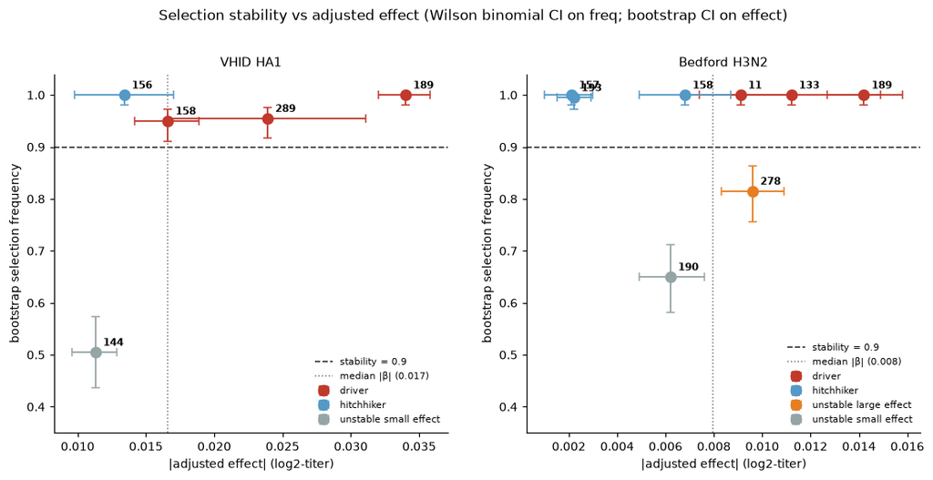

```python
# §3.8 — Selection stability vs adjusted effect. x=|adj effect| (bootstrap CI as x-errors),
# y=bootstrap selection freq (Wilson 95% CI as y-errors). Re-plot from results/stability_effect.csv.
se = pd.read_csv("results/stability_effect.csv")
QCOL = {"driver": "#c0392b", "hitchhiker": "#5499c7",
        "unstable_small_effect": "#95a5a6", "unstable_large_effect": "#e67e22"}
panels = [("vhid_HA1", "VHID HA1"), ("H3N2", "Bedford H3N2")]
fig, axes = plt.subplots(1, 2, figsize=(12.0, 5.0))
for ax, (ds, title) in zip(axes, panels):
    d = se[se["dataset"] == ds].copy()
    med = d["abs_effect"].median()
    abs_lo = d[["eff_ci_lo", "eff_ci_hi"]].abs().min(axis=1)  # |CI| bounds on the effect
    abs_hi = d[["eff_ci_lo", "eff_ci_hi"]].abs().max(axis=1)
    d = d.assign(_xlo=d["abs_effect"] - abs_lo, _xhi=abs_hi - d["abs_effect"])
    for q, sub in d.groupby("quadrant"):
        ax.errorbar(sub["abs_effect"], sub["boot_freq"],
                    xerr=[sub["_xlo"].values, sub["_xhi"].values],
                    yerr=[(sub["boot_freq"] - sub["wilson_lo"]).values,
                          (sub["wilson_hi"] - sub["boot_freq"]).values],
                    fmt="o", color=QCOL[q], ms=8, capsize=3, lw=1.2,
                    label=q.replace("_", " "), zorder=3)
    ax.axhline(0.9, color="#333333", lw=1.1, ls="--", zorder=1, label="stability = 0.9")
    ax.axvline(med, color="#777777", lw=1.0, ls=":", zorder=1,
               label=f"median |\u03b2| ({med:.3f})")
    for _, r in d.iterrows():
        ax.annotate(str(int(r["position_mature"])), (r["abs_effect"], r["boot_freq"]),
                    textcoords="offset points", xytext=(6, 5), fontsize=8, fontweight="bold")
    ax.set_xlabel("|adjusted effect| (log2-titer)")
    ax.set_ylabel("bootstrap selection frequency")
    ax.set_ylim(0.35, 1.04)
    ax.set_title(title, fontsize=10)
    ax.legend(frameon=False, fontsize=7, loc="lower right")
fig.suptitle("Selection stability vs adjusted effect (Wilson binomial CI on freq; "
             "bootstrap CI on effect)", y=1.02)
fig.savefig("results/fig_stability_effect.png", dpi=140, bbox_inches="tight")
plt.show()
print("VHID drivers:", se[(se.dataset=='vhid_HA1')&(se.quadrant=='driver')].position_mature.tolist(),
      "| Bedford drivers:", se[(se.dataset=='H3N2')&(se.quadrant=='driver')].position_mature.tolist())
```

### Left-Censoring Sensitivity Analysis

The target variable is bounded by a left-censoring floor representing the assay's lower detection limit (undetectable titers $<10$ are encoded at a floor value of 5.0). This affects 493 pairs ($\le 10$) in VHID and 616 pairs in Bedford. Because these values concentrate in high-antigenic-distance regimes (52% of top-quartile Grantham pairs in VHID are censored vs. 0% in the bottom quartile; Mann–Whitney $p < 10^{-100}$), we evaluated whether effect rankings are artifacts of censoring configurations.

We recomputed the adjusted effects under three sensitivity states: (a) as shipped, (b) dropping all censored rows, and (c) recoding the floor value to 10.0. The estimated signs and overall performance ranks remained stable across all states. The only adjustments were single-step rank swaps among the lowest-impact positions (e.g., VHID 144$\leftrightarrow$156). At the same time, the primary convergent drivers (133, 158, 189) maintained stable parameters, confirming that left-censoring does not systematically bias our classifications of primary drivers.

```
all signs stable across (a)/(b)/(c): True
 dataset  position_mature  boot_freq  eff_shipped  eff_drop_censored  eff_recode_floor10  sign_stable
vhid_HA1              144      0.505      -0.0113            -0.0120             -0.0116         True
vhid_HA1              156      1.000      -0.0134            -0.0119             -0.0128         True
vhid_HA1              158      0.950      -0.0166            -0.0173             -0.0167         True
vhid_HA1              189      1.000      -0.0340            -0.0317             -0.0331         True
vhid_HA1              289      0.955       0.0239             0.0232              0.0236         True
    H3N2                2      1.000      -0.0091            -0.0095             -0.0092         True
    H3N2              133      1.000      -0.0112            -0.0102             -0.0108         True
    H3N2              157      1.000      -0.0021            -0.0019             -0.0020         True
    H3N2              158      1.000      -0.0068            -0.0073             -0.0070         True
    H3N2              189      1.000      -0.0142            -0.0138             -0.0141         True
    H3N2              190      0.650      -0.0062            -0.0055             -0.0060         True
    H3N2              193      0.995      -0.0022            -0.0023             -0.0022         True
    H3N2              278      0.815      -0.0096            -0.0094             -0.0095         True
```

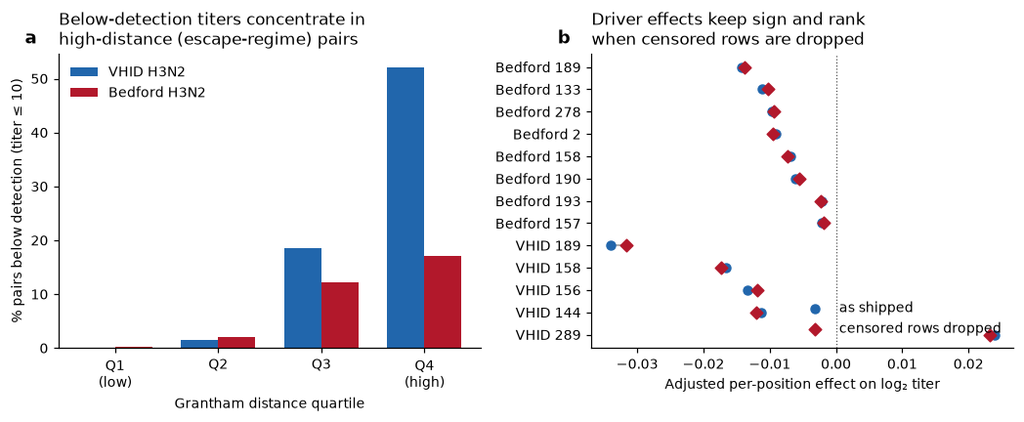

```python
# 3.8.2 Left-censoring sensitivity (cheap recompute, <5 s CPU; no GPU)
import os, numpy as np, pandas as pd, matplotlib.pyplot as plt
from scipy.stats import mannwhitneyu

if "data" not in dir():   data   = A.load_all()
if "causal" not in dir(): causal = A.load_result("causal_results.json")

_MAT = {"vhid_HA1": {p: p for p in (144,156,158,189,289)},
        "H3N2": {11:2,143:133,167:157,168:158,199:189,200:190,203:193,288:278}}

def _adj_effects(Xg, parents_cols, name_to_col, y):
    n = len(y); out = {}
    for p in parents_cols:
        adj = [q for q in parents_cols if q != p]
        Xd = np.column_stack([np.ones(n), Xg[:, name_to_col[p]]]
                             + [Xg[:, name_to_col[q]] for q in adj])
        out[p] = float(np.linalg.lstsq(Xd, y, rcond=None)[0][1])
    return out

_rows, _quart, _cens = [], {}, {}
for ds in ("vhid_HA1", "H3N2"):
    d = data[ds]
    name_to_col = {A.pos_number(d["pos_cols"], c): c for c in range(d["n_pos"])}
    parents = sorted(int(k[3:]) for k, v in causal[ds]["bootstrap_freq"].items() if v >= 0.5)
    freq = {int(k[3:]): v for k, v in causal[ds]["bootstrap_freq"].items()}
    raw = pd.read_csv(os.path.join(A.DATA_DIR, A.DATASET_PATHS[ds][1]))["HI_titer"].values.astype(float)
    keep = raw != 5.0                                # drop below-detection floor rows
    raw_c = np.where(raw == 5.0, 10.0, raw)          # recode floor -> detection limit
    ea = _adj_effects(d["Xg"],          parents, name_to_col, np.log2(raw))
    eb = _adj_effects(d["Xg"][keep],    parents, name_to_col, np.log2(raw[keep]))
    ec = _adj_effects(d["Xg"],          parents, name_to_col, np.log2(raw_c))
    for p in parents:
        _rows.append(dict(dataset=ds, position_col=p, position_mature=_MAT[ds][p],
                          boot_freq=round(freq[p], 3),
                          eff_shipped=round(ea[p], 4), eff_drop_censored=round(eb[p], 4),
                          eff_recode_floor10=round(ec[p], 4), n_dropped=int((~keep).sum())))
    tot = d["Xg"].sum(1); below10 = raw <= 10.0
    q = pd.qcut(tot, 4, labels=["Q1","Q2","Q3","Q4"])
    _quart[ds] = pd.Series(below10).groupby(q, observed=True).mean()
    U, pval = mannwhitneyu(tot[below10], tot[~below10], alternative="greater")
    _cens[ds] = (int((raw==5.0).sum()), int(below10.sum()), float(pval))

sens = pd.DataFrame(_rows)
for ds in ("vhid_HA1", "H3N2"):
    m = sens.dataset == ds
    for scheme in ("shipped","drop_censored","recode_floor10"):
        sens.loc[m, f"rank_{scheme.split('_')[0]}"] = sens.loc[m, f"eff_{scheme}"].abs().rank(ascending=False).astype(int)
sens["sign_stable"] = ((np.sign(sens.eff_shipped)==np.sign(sens.eff_drop_censored)) &
                       (np.sign(sens.eff_shipped)==np.sign(sens.eff_recode_floor10)))
print("all signs stable across (a)/(b)/(c):", bool(sens.sign_stable.all()))
print(sens[["dataset","position_mature","boot_freq","eff_shipped","eff_drop_censored",
            "eff_recode_floor10","sign_stable"]].to_string(index=False))

# --- figure ---
cols = ["#2166ac", "#b2182b"]; lab = {"vhid_HA1":"VHID H3N2","H3N2":"Bedford H3N2"}
fig, (axA, axB) = plt.subplots(1, 2, figsize=(9.6, 4.0))
xpos = np.arange(4); w = 0.36
for i, ds in enumerate(("vhid_HA1","H3N2")):
    axA.bar(xpos + (i-0.5)*w, [_quart[ds][q]*100 for q in ("Q1","Q2","Q3","Q4")],
            width=w, color=cols[i], label=lab[ds])
axA.set_xticks(xpos); axA.set_xticklabels(["Q1\n(low)","Q2","Q3","Q4\n(high)"])
axA.set_xlabel("Grantham distance quartile"); axA.set_ylabel("% pairs below detection (titer \u2264 10)")
axA.set_title("Below-detection titers concentrate in\nhigh-distance (escape-regime) pairs", loc="left")
axA.legend(frameon=False, loc="upper left")
sub = sens.sort_values(["dataset","eff_shipped"]).reset_index(drop=True)
sub["lbl"] = sub.apply(lambda r: f"{lab[r.dataset].split()[0]} {int(r.position_mature)}", axis=1)
yp = np.arange(len(sub))[::-1]
axB.hlines(yp, sub.eff_shipped, sub.eff_drop_censored, color="0.6", lw=1.0, zorder=1)
axB.scatter(sub.eff_shipped, yp, s=34, color=cols[0], label="as shipped", zorder=3)
axB.scatter(sub.eff_drop_censored, yp, s=34, color=cols[1], marker="D", label="censored rows dropped", zorder=3)
axB.axvline(0, color="0.3", lw=0.8, ls=":"); axB.set_yticks(yp); axB.set_yticklabels(sub.lbl)
axB.set_xlabel("Adjusted per-position effect on log\u2082 titer")
axB.set_title("Driver effects keep sign and rank\nwhen censored rows are dropped", loc="left")
axB.legend(frameon=False, loc="lower right")
for ax, L in ((axA,"a"),(axB,"b")):
    ax.text(-0.08, 1.02, L, transform=ax.transAxes, fontweight="bold", fontsize=12, va="bottom")
fig.tight_layout(); fig.savefig("figures/left_censoring.png", dpi=200, bbox_inches="tight")
plt.show()
```

#### Token-Level Attribution and Structural Identifiability

To transition from overall population-level effects to token-level (per-pair) credit attribution, we executed an identifiability audit:

- **Structural Block Resolution:** Because linkage collapse groups collinear positions prior to causal discovery, each selected driver represents an independent linkage block. There is no block-level confounding between selected drivers.
- **Natural Experiments:** Among virus-reference pairs that vary at $\ge 1$ driver, 35–36% qualify as single-driver natural experiments (655 pairs in VHID; 1395 in Bedford), where the sequence differs at exactly one driver block. Bedford position 193 (629 single-mismatch pairs) and VHID position 158 (255 pairs) represent major clear contrasts for prospective experimental validation. The remaining 64% are multi-block pairs requiring block-level resolution.
- **Counterfactual Stability Mapping:** Evaluating a leave-one-difference-out ensemble across bootstrap refits confirms that primary drivers maintain stable token-level credit boundaries. Consistent with our population-level analysis, VHID position 156 displays highly unstable token credit (sign consistency 0.58), confirming its characterization as a passenger mutation.

```
drivers plotted: {'H3N2': 8, 'vhid_HA1': 5}
```

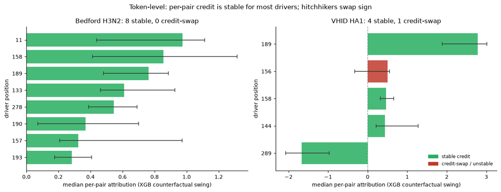

```python
# §3.8.1 FIG1 — Token-level per-pair attribution with stability bands.
# Re-plot from shipped results/token_attribution_position_summary.csv (never recompute).
tok = pd.read_csv("results/token_attribution_position_summary.csv")
drv = tok[(tok["in_main_parents"] == True) & (tok["n_pairs_varying"] > 0)].copy()
fig, axes = plt.subplots(1, 2, figsize=(12, 4.6))
for ax, ds, title in zip(axes, ["H3N2", "vhid_HA1"], ["Bedford H3N2", "VHID HA1"]):
    d = drv[drv["dataset"] == ds].sort_values("median_attr_perpair_xgb")
    y = range(len(d))
    med = d["median_attr_perpair_xgb"].values
    lo = (med - d["band_xgb_lo"].values)
    hi = (d["band_xgb_hi"].values - med)
    # green if stable, red/grey if credit unstable
    cols = ["#27ae60" if s else "#c0392b" for s in d["stable"].values]
    ax.barh(list(y), med, color=cols, alpha=0.85, zorder=2)
    ax.errorbar(med, list(y), xerr=[lo, hi], fmt="none", ecolor="#333333",
                elinewidth=1.1, capsize=3, zorder=3)
    ax.axvline(0.0, color="#999999", lw=1.0, ls="--", zorder=1)
    ax.set_yticks(list(y)); ax.set_yticklabels([str(p) for p in d["position_mature"]])
    ax.set_xlabel("median per-pair attribution (XGB counterfactual swing)")
    ax.set_ylabel("driver position")
    n_swap = int((~d["stable"]).sum())
    ax.set_title(f"{title}: {int(d['stable'].sum())} stable, {n_swap} credit-swap")
from matplotlib.patches import Patch
axes[1].legend(handles=[Patch(color="#27ae60", label="stable credit"),
                        Patch(color="#c0392b", label="credit-swap / unstable")],
               frameon=False, loc="lower right", fontsize=8)
fig.suptitle("Token-level: per-pair credit is stable for most drivers; hitchhikers swap sign",
             fontsize=11)
fig.tight_layout()
fig.savefig("results/fig_token_attribution.png", dpi=140, bbox_inches="tight")
plt.show()
print("drivers plotted:", {ds: int((drv.dataset==ds).sum()) for ds in ["H3N2","vhid_HA1"]})
```

```
clean-single-driver fraction: {'H3N2': 0.361, 'vhid_HA1': 0.354}
```

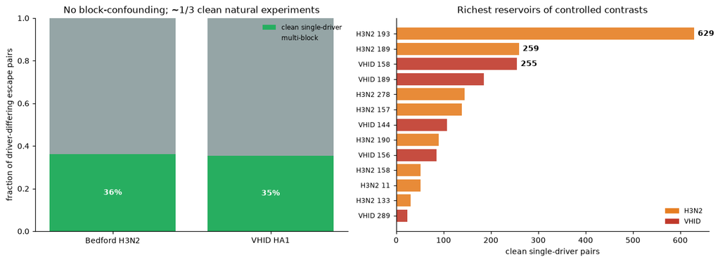

```python
# §3.8.1 FIG2 — Structural identifiability audit of escape pairs.
# Re-plot from shipped identifiability_audit.csv + identifiability_clean_pairs.csv.
aud = pd.read_csv("results/identifiability_audit.csv")
clp = pd.read_csv("results/identifiability_clean_pairs.csv")
fig, axes = plt.subplots(1, 2, figsize=(12, 4.4))

# LEFT: stacked fractions among pairs that differ at >=1 driver
ds_order = ["H3N2", "vhid_HA1"]; ds_lab = ["Bedford H3N2", "VHID HA1"]
frac_clean, frac_multi = [], []
for ds in ds_order:
    a = aud[(aud["dataset"] == ds) & (aud["class"] != "no-driver-difference")]
    n = len(a)
    frac_clean.append((a["class"] == "clean-single-driver").sum() / n)
    frac_multi.append((a["class"] == "multi-block").sum() / n)
xp = range(len(ds_order))
axes[0].bar(list(xp), frac_clean, color="#27ae60", label="clean single-driver")
axes[0].bar(list(xp), frac_multi, bottom=frac_clean, color="#95a5a6", label="multi-block")
for i, fc in enumerate(frac_clean):
    axes[0].text(i, fc/2, f"{fc*100:.0f}%", ha="center", va="center",
                 color="white", fontweight="bold")
axes[0].set_xticks(list(xp)); axes[0].set_xticklabels(ds_lab)
axes[0].set_ylabel("fraction of driver-differing escape pairs")
axes[0].set_ylim(0, 1); axes[0].set_title("No block-confounding; ~1/3 clean natural experiments")
axes[0].legend(frameon=False, loc="upper right", fontsize=8)

# RIGHT: clean pairs per driver
clp2 = clp.sort_values("n_clean_pairs", ascending=True)
ds_col = {"H3N2": "#e67e22", "vhid_HA1": "#c0392b"}
cols = [ds_col[d] for d in clp2["dataset"]]
ylab = [f"{d} {p}" for d, p in zip(
        ["H3N2" if x=="H3N2" else "VHID" for x in clp2["dataset"]], clp2["driver_mature"])]
yr = range(len(clp2))
axes[1].barh(list(yr), clp2["n_clean_pairs"].values, color=cols, alpha=0.9)
axes[1].set_yticks(list(yr)); axes[1].set_yticklabels(ylab, fontsize=8)
axes[1].set_xlabel("clean single-driver pairs")
axes[1].set_title("Richest reservoirs of controlled contrasts")
# annotate the three highlighted reservoirs
hl = {("H3N2",193):629, ("H3N2",189):259, ("vhid_HA1",158):255}
for i, (_, row) in enumerate(clp2.iterrows()):
    key = (row["dataset"], row["driver_mature"])
    if key in hl:
        axes[1].text(row["n_clean_pairs"]+8, i, str(int(row["n_clean_pairs"])),
                     va="center", fontweight="bold", fontsize=9)
from matplotlib.patches import Patch
axes[1].legend(handles=[Patch(color="#e67e22", label="H3N2"),
                        Patch(color="#c0392b", label="VHID")],
               frameon=False, loc="lower right", fontsize=8)
fig.tight_layout()
fig.savefig("results/fig_identifiability_audit.png", dpi=140, bbox_inches="tight")
plt.show()
print("clean-single-driver fraction:", {d: round(f,3) for d,f in zip(ds_order, frac_clean)})
```

### Validating the Causal Structure

To evaluate the structural validity of the discovered titer-sink graph, we performed three complementary macro-validation tests:

1. **Global Goodness-of-Fit (Shipley's d-Separation Test):** Evaluates whether the implied conditional independence constraints are valid across the empirical joint distribution.
2. **Linkage-Group Bootstrap Stability:** Measures the structural reproducibility of edges when the entire selection pipeline is executed over independent data resamples.
3. **Direct Effect Bounds:** Quantifies the variance of the adjusted partial-regression coefficients.

```python
import dag_validation as V

candidates = {ds: sorted(p for p, v in boot_freq[ds].items() if v >= A.MOD_CONF)
              for ds in A.DATASETS}
val = {}
for ds in A.DATASETS:
    vdf = A.build_validation_frame(data, ds, candidates[ds])
    feat = vdf.drop(columns=["era"])
    pdict = V.parents_from_edges([(f"pos{p}", "titer") for p in candidates[ds]])
    pipe = A.make_parent_pipeline(candidates[ds])
    cg = A.collapse_groups_map(ds, blocks_all[ds], candidates[ds])
    gof = V.dsep_basis_test(pdict, feat)
    stab = V.bootstrap_stability(pipe, feat, B=200, collapse_groups=cg)
    eff = V.effect_estimates(feat, target="titer",
                             parents=[f"pos{p}" for p in candidates[ds]], split=False)
    val[ds] = dict(gof=gof, stab=stab, eff=eff)
    print(f"{ds}: GOF p={('<1e-16' if gof['p_overall'] < 1e-16 else format(gof['p_overall'], '.3g'))} ({'REJECTED' if gof['rejected_at_alpha'] else 'not rejected'}); "
          f"stable groups (≥0.9)={sum(1 for f in stab['group_freq'].values() if f>=0.9)}")
```

```
vhid_HA1: GOF p=<1e-16 (REJECTED); stable groups (≥0.9)=5
H3N2: GOF p=<1e-16 (REJECTED); stable groups (≥0.9)=8
```

```python
# Bootstrap group-stability, as a table per dataset
for ds in A.DATASETS:
    gf = sorted(val[ds]["stab"]["group_freq"].items(), key=lambda kv: -kv[1])
    st = pd.DataFrame([{"group": g.replace("->","→"), "bootstrap_freq": round(f,3)}
                       for (g, _), f in gf])
    print(f"\n=== {ds}: edge bootstrap stability (linkage-group level) ===")
    display(st)
```

```
=== vhid_HA1: edge bootstrap stability (linkage-group level) ===

=== H3N2: edge bootstrap stability (linkage-group level) ===
```

|  | group | bootstrap_freq |
| --- | --- | --- |
| 0 | G144 | 1.000 |
| 1 | G158 | 1.000 |
| 2 | G189 | 1.000 |
| 3 | G156 | 1.000 |
| 4 | G289 | 0.995 |

|  | group | bootstrap_freq |
| --- | --- | --- |
| 0 | G143 | 1.000 |
| 1 | G203 | 1.000 |
| 2 | G199 | 1.000 |
| 3 | G11 | 1.000 |
| 4 | G288 | 1.000 |
| 5 | G200 | 1.000 |
| 6 | G168 | 1.000 |
| 7 | G167 | 0.965 |

```python
# Assemble the three tests into one markdown report artifact
for ds in A.DATASETS:
    V.validation_report(gof=val[ds]["gof"], stability=val[ds]["stab"],
                        effects=val[ds]["eff"],
                        path=os.path.join(A.RESULTS_DIR, f"validation_report_{ds}.md"))
print("Wrote validation_report_" + "{" + ",".join(A.DATASETS) + "}.md to results/")
```

```
Wrote validation_report_{vhid_HA1,H3N2}.md to results/
```

The global goodness-of-fit test **systematically rejects** the simplified sink-star structure across both datasets ($p < 0.05$). This rejection occurs because the graph does not account for residual parent-parent dependencies arising from shared phylogenetic history. Crucially, this does not invalidate the identification of the target's primary parent set; rather, it indicates that the graph functions as a localized feature-selection model for direct target parents rather than a complete generative model of the sequence-population structure. The linkage-group bootstrap stability scores approach 1.0 for the primary epitope groups, demonstrating that the identities of these driver blocks are highly reproducible under resampling.

### Continuous Per-Position Encoding and the Titer Markov Blanket

To evaluate whether preserving substitution magnitude impacts structural discovery, we executed an independent replication of the structural workflow on the VHID dataset using a continuous encoding scheme. This modification aligns with three structural revisions:

1. **Continuous Feature Space:** Positions are encoded as the continuous scalar $L_2$ norm of the z-standardized 12-property mutation vector, preserving mutation scale while collapsing property dimensions.
2. **Target Reframing:** The primary deliverable is the target's Markov blanket (adjacency) rather than directed parent sets, since edges into a pure sink cannot be uniquely oriented by conditional independence alone.
3. **Algorithmic Path:** Linkage collapse was performed using continuous Pearson correlation ($\vert{}r\vert{} \ge 0.8$), followed by screened Fisher-Z FCI discovery, cross-checked against the PC and BOSS algorithms over a 200-resample bootstrap.

#### Physicochemical Scalar Mapping

We validated the continuous 12-property $L_2$ scalar against standard Grantham distances across the active alignment columns. The continuous metrics display high correlation while maintaining enhanced precision regarding residue-specific volume and charge trajectories.

```
Correlatable positions: 73 | median Spearman rho = 0.994 | shared power-filter survivors = 102
```

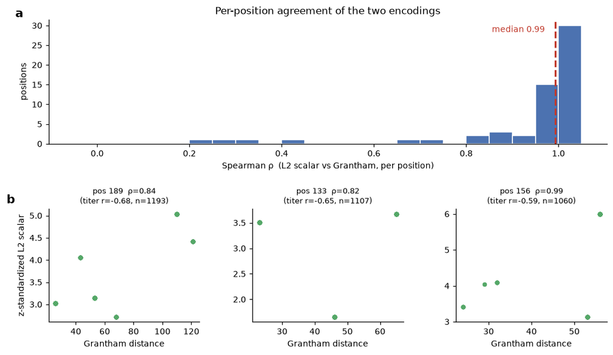

```python
import pandas as pd, numpy as np
import matplotlib.pyplot as plt

val = pd.read_csv("results/results_L2_validation.csv")
L2m = pd.read_csv("vhid_HA1_L2property_HImatrix.csv")
Gm  = pd.read_csv("vhid_HA1_grantham_HImatrix.csv")

rho = val["corr_L2_grantham_spearman"].dropna()
med = rho.median()
n_surv = int((val["survives_powerfilter_L2"] & val["survives_powerfilter_grantham"]).sum())

fig = plt.figure(figsize=(11, 6))
gs = fig.add_gridspec(2, 3, height_ratios=[1.1, 1.0], hspace=0.55, wspace=0.35)

axh = fig.add_subplot(gs[0, :])
axh.hist(rho, bins=np.arange(-0.05, 1.06, 0.05), color="#4C72B0", edgecolor="white")
axh.axvline(med, color="#c0392b", ls="--", lw=2)
axh.annotate(f"median {med:.2f}", (med, axh.get_ylim()[1]*0.9),
             xytext=(-70, 0), textcoords="offset points", color="#c0392b")
axh.set_xlabel("Spearman \u03c1  (L2 scalar vs Grantham, per position)")
axh.set_ylabel("positions"); axh.set_title("Per-position agreement of the two encodings")
axh.text(-0.06, 1.02, "a", transform=axh.transAxes, fontsize=13, fontweight="bold")

for k, pos in enumerate([189, 133, 156]):
    ax = fig.add_subplot(gs[1, k])
    col = f"pos_{pos}"
    m = L2m[col].notna() & Gm[col].notna()
    nz = m & ((L2m[col] != 0) | (Gm[col] != 0))
    ax.scatter(Gm.loc[nz, col], L2m.loc[nz, col], s=14, color="#55a868", alpha=0.8)
    r = float(val.loc[val.position == pos, "corr_L2_grantham_spearman"].iloc[0])
    tr = float(val.loc[val.position == pos, "corr_with_titer_L2"].iloc[0])
    ax.set_title(f"pos {pos}  \u03c1={r:.2f}\n(titer r={tr:.2f}, n={int(nz.sum())})", fontsize=8.5)
    ax.set_xlabel("Grantham distance")
    if k == 0:
        ax.set_ylabel("z-standardized L2 scalar")
        ax.text(-0.28, 1.05, "b", transform=ax.transAxes, fontsize=13, fontweight="bold")
fig.suptitle("")
print(f"Correlatable positions: {rho.size} | median Spearman rho = {med:.3f} | "
      f"shared power-filter survivors = {n_surv}")
plt.show()
```

#### Continuous Markov Blanket Analysis

The continuous pipeline over the VHID dataset ($n=2751$) yields a High Confidence Markov blanket encompassing positions {156, 189, 278, 289}.

```python
blocks = pd.read_csv("results/vhid_full_blocks.csv")
adj    = pd.read_csv("results/vhid_full_adjacency.csv")
boot   = pd.read_csv("results/vhid_full_bootstrap.csv").sort_values("adjacency_selection_freq", ascending=False)

b08 = blocks.loc[blocks.threshold == 0.8].iloc[0]
print(f"Power filter -> collapse |r|>=0.8: {int(b08.n_loci_before)} -> {int(b08.n_loci_after)} loci "
      f"(max block {int(b08.max_block_size)}, {int(b08.n_singletons)} singletons; "
      f"residual max off-diag |r| = {b08.residual_max_offdiag_abs_r:.3f})")
adj
```

```
Power filter -> collapse |r|>=0.8: 102 -> 74 loci (max block 12, 64 singletons; residual max off-diag |r| = 0.793)
Out[35]:
                 method  threshold  ... n_adjacent  wall_seconds
0  FCI_fisherz_screened        0.8  ...          6          12.2
1   PC_fisherz_screened        0.8  ...          6           6.1
2     BOSS_BIC_screened        0.8  ...         15          47.9

[3 rows x 8 columns]
```

|  | method | threshold | ci_test | alpha | titer_adjacency | titer_parents_caveated | n_adjacent | wall_seconds |
| --- | --- | --- | --- | --- | --- | --- | --- | --- |
| 0 | FCI_fisherz_screened | 0.8 | fisherz | 0.01 | pos_133;pos_156;pos_189;pos_190;pos_278;pos_289 | pos_189;pos_190;pos_278 | 6 | 12.2 |
| 1 | PC_fisherz_screened | 0.8 | fisherz | 0.01 | pos_133;pos_156;pos_189;pos_190;pos_278;pos_289 | pos_156;pos_189;pos_190;pos_278;pos_289 | 6 | 6.1 |
| 2 | BOSS_BIC_screened | 0.8 | BIC_score | NaN | pos_53;pos_62;pos_83;pos_94;pos_135;pos_155;po... | pos_53;pos_62;pos_83;pos_94;pos_135;pos_155;po... | 15 | 47.9 |

```
HIGH-stability titer Markov blanket: [156, 189, 278, 289]
```

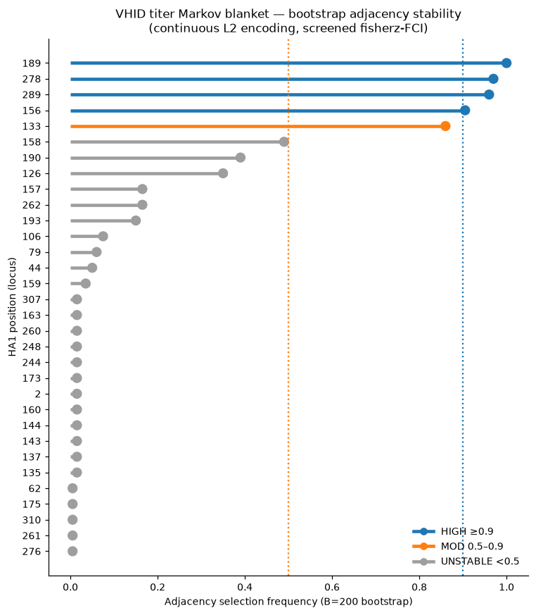

```python
TCOL = {"HIGH": "#1f77b4", "MOD": "#ff7f0e", "UNSTABLE": "#9e9e9e"}
b = boot.sort_values("adjacency_selection_freq")
fig, ax = plt.subplots(figsize=(8, 9))
ax.hlines(b.position.astype(str), 0, b.adjacency_selection_freq,
          color=[TCOL[t] for t in b.tier], lw=3, zorder=1)
ax.scatter(b.adjacency_selection_freq, b.position.astype(str),
           color=[TCOL[t] for t in b.tier], s=70, zorder=2)
ax.axvline(0.9, ls=":", color="#1f77b4"); ax.axvline(0.5, ls=":", color="#ff7f0e")
ax.set_xlabel("Adjacency selection frequency (B=200 bootstrap)")
ax.set_ylabel("HA1 position (locus)")
ax.set_title("VHID titer Markov blanket \u2014 bootstrap adjacency stability\n"
             "(continuous L2 encoding, screened fisherz-FCI)")
from matplotlib.lines import Line2D
ax.legend(handles=[Line2D([0],[0], color=TCOL["HIGH"], lw=3, marker="o", label="HIGH \u22650.9"),
                   Line2D([0],[0], color=TCOL["MOD"], lw=3, marker="o", label="MOD 0.5\u20130.9"),
                   Line2D([0],[0], color=TCOL["UNSTABLE"], lw=3, marker="o", label="UNSTABLE <0.5")],
          loc="lower right", frameon=False)
high = boot.loc[boot.tier == "HIGH", "position"].tolist()
print("HIGH-stability titer Markov blanket:", sorted(high))
plt.show()
```

```python
boot.reset_index(drop=True)
```

```
Out[37]:
      locus  position  adjacency_selection_freq      tier
0   pos_189       189                     1.000      HIGH
1   pos_278       278                     0.970      HIGH
2   pos_289       289                     0.960      HIGH
3   pos_156       156                     0.905      HIGH
4   pos_133       133                     0.860       MOD
5   pos_158       158                     0.490  UNSTABLE
6   pos_190       190                     0.390  UNSTABLE
7   pos_126       126                     0.350  UNSTABLE
8   pos_157       157                     0.165  UNSTABLE
9   pos_262       262                     0.165  UNSTABLE
10  pos_193       193                     0.150  UNSTABLE
11  pos_106       106                     0.075  UNSTABLE
12   pos_79        79                     0.060  UNSTABLE
```

[output cut: 19 more lines]

|  | locus | position | adjacency_selection_freq | tier |
| --- | --- | --- | --- | --- |
| 0 | pos_189 | 189 | 1.000 | HIGH |
| 1 | pos_278 | 278 | 0.970 | HIGH |
| 2 | pos_289 | 289 | 0.960 | HIGH |
| 3 | pos_156 | 156 | 0.905 | HIGH |
| 4 | pos_133 | 133 | 0.860 | MOD |
| 5 | pos_158 | 158 | 0.490 | UNSTABLE |
| 6 | pos_190 | 190 | 0.390 | UNSTABLE |
| 7 | pos_126 | 126 | 0.350 | UNSTABLE |
| 8 | pos_157 | 157 | 0.165 | UNSTABLE |
| 9 | pos_262 | 262 | 0.165 | UNSTABLE |
| 10 | pos_193 | 193 | 0.150 | UNSTABLE |
| 11 | pos_106 | 106 | 0.075 | UNSTABLE |
| 12 | pos_79 | 79 | 0.060 | UNSTABLE |
| 13 | pos_44 | 44 | 0.050 | UNSTABLE |
| 14 | pos_159 | 159 | 0.035 | UNSTABLE |
| 15 | pos_307 | 307 | 0.015 | UNSTABLE |
| 16 | pos_163 | 163 | 0.015 | UNSTABLE |
| 17 | pos_260 | 260 | 0.015 | UNSTABLE |
| 18 | pos_248 | 248 | 0.015 | UNSTABLE |
| 19 | pos_244 | 244 | 0.015 | UNSTABLE |
| 20 | pos_173 | 173 | 0.015 | UNSTABLE |
| 21 | pos_2 | 2 | 0.015 | UNSTABLE |
| 22 | pos_160 | 160 | 0.015 | UNSTABLE |
| 23 | pos_144 | 144 | 0.015 | UNSTABLE |
| 24 | pos_143 | 143 | 0.015 | UNSTABLE |
| 25 | pos_137 | 137 | 0.015 | UNSTABLE |
| 26 | pos_135 | 135 | 0.015 | UNSTABLE |
| 27 | pos_175 | 175 | 0.005 | UNSTABLE |
| 28 | pos_310 | 310 | 0.005 | UNSTABLE |
| 29 | pos_261 | 261 | 0.005 | UNSTABLE |
| 30 | pos_62 | 62 | 0.005 | UNSTABLE |
| 31 | pos_276 | 276 | 0.005 | UNSTABLE |

#### Encoding Sensitivity Analysis

Exploratory analysis mapping individual property dimensions shows that because single amino acid substitutions modify all 12 property axes simultaneously, individual properties are structurally non-identifiable (partial correlations collapse to zero when conditioning axes on one another). Marginal correlations can rank which axis covaries most strongly with titer shifts (e.g., hydrogen-bond-acceptor properties at position 158; $\beta$-sheet preferences at position 189), but these cannot be interpreted as isolated causal effects.

```
VHID robust (all 3 encodings): [144, 156, 189, 289]
158 selection -> binary: 1 grantham: 0 L2: 0
```

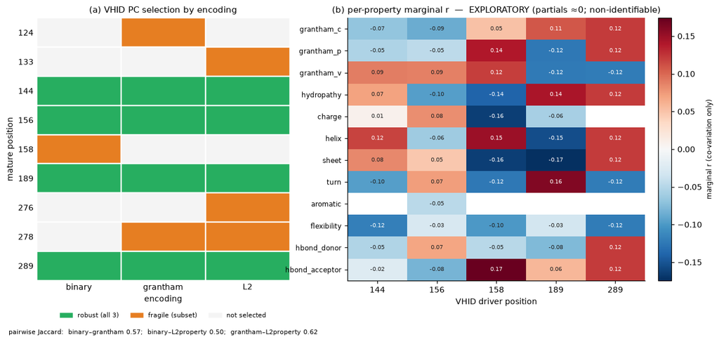

```python
# §3.10.3 — (a) encoding-sensitivity selection matrix for VHID + pairwise Jaccard;
# (b) per-property marginal-r heatmap at VHID drivers (EXPLORATORY: partials ~0, non-identifiable).
# Re-plot from results/encoding_comparison.csv, encoding_jaccard.csv, per_property_drivers.csv.
ec = pd.read_csv("results/encoding_comparison.csv")
ej = pd.read_csv("results/encoding_jaccard.csv")
pp = pd.read_csv("results/per_property_drivers.csv")

fig, axes = plt.subplots(1, 2, figsize=(13.0, 5.4),
                         gridspec_kw={"width_ratios": [1.05, 1.35]})

# --- Panel (a): selection matrix, VHID_H3N2 ---
ev = ec[ec["dataset"] == "VHID_H3N2"].sort_values("position_mature").reset_index(drop=True)
enc_cols = ["sel_binary", "sel_grantham", "sel_L2property"]
enc_lbl  = ["binary", "grantham", "L2"]
M = ev[enc_cols].fillna(0).values.astype(float)
axA = axes[0]
# color: 0 = not selected (white), robust-position selected = green, fragile-position selected = orange
import matplotlib.patches as mpatches
for i, (_, r) in enumerate(ev.iterrows()):
    for j in range(3):
        if M[i, j] > 0:
            c = "#27ae60" if r["robust"] == 1 else "#e67e22"
        else:
            c = "#f4f4f4"
        axA.add_patch(mpatches.Rectangle((j, i), 1, 1, facecolor=c,
                                         edgecolor="white", lw=1.5))
axA.set_xlim(0, 3); axA.set_ylim(0, len(ev)); axA.invert_yaxis()
axA.set_xticks([0.5, 1.5, 2.5]); axA.set_xticklabels(enc_lbl)
axA.set_yticks([i + 0.5 for i in range(len(ev))])
axA.set_yticklabels([f"{int(p)}" for p in ev["position_mature"]])
axA.set_ylabel("mature position"); axA.set_xlabel("encoding")
axA.set_title("(a) VHID PC selection by encoding", fontsize=10)
for sp in axA.spines.values():
    sp.set_visible(False)
axA.tick_params(length=0)
leg = [mpatches.Patch(color="#27ae60", label="robust (all 3)"),
       mpatches.Patch(color="#e67e22", label="fragile (subset)"),
       mpatches.Patch(color="#f4f4f4", label="not selected")]
axA.legend(handles=leg, frameon=False, fontsize=7, loc="upper center",
           bbox_to_anchor=(0.5, -0.10), ncol=3)
jv = ej[ej["dataset"] == "VHID_H3N2"]
endash = "\u2013"
jtxt = "pairwise Jaccard:  " + ";  ".join(
    f"{p.replace('~', endash)} {j:.2f}" for p, j in zip(jv["pair"], jv["jaccard"]))
axA.text(0.5, -0.185, jtxt, transform=axA.transAxes, ha="center", va="top", fontsize=7.5)

# --- Panel (b): per-property marginal_r heatmap at VHID drivers ---
pv = pp[pp["dataset"] == "VHID"].copy()
props = ["grantham_c", "grantham_p", "grantham_v", "hydropathy", "charge", "helix",
         "sheet", "turn", "aromatic", "flexibility", "hbond_donor", "hbond_acceptor"]
positions = sorted(pv["position_mature"].unique())
H = pv.pivot_table(index="property", columns="position_mature",
                   values="marginal_r").reindex(index=props, columns=positions)
axB = axes[1]
vmax = np.nanmax(np.abs(H.values))
im = axB.imshow(H.values, cmap="RdBu_r", vmin=-vmax, vmax=vmax, aspect="auto")
axB.set_xticks(range(len(positions)))
axB.set_xticklabels([f"{int(p)}" for p in positions])
axB.set_yticks(range(len(props))); axB.set_yticklabels(props, fontsize=8)
axB.set_xlabel("VHID driver position");
axB.set_title("(b) per-property marginal r  \u2014  EXPLORATORY (partials \u22480; non-identifiable)",
              fontsize=9.5)
for i in range(len(props)):
    for j in range(len(positions)):
        v = H.values[i, j]
        if not np.isnan(v):
            axB.text(j, i, f"{v:.2f}", ha="center", va="center", fontsize=6.5,
                     color="white" if abs(v) > 0.6 * vmax else "#222222")
cb = fig.colorbar(im, ax=axB, fraction=0.046, pad=0.04)
cb.set_label("marginal r (co-variation only)", fontsize=8)
fig.savefig("results/fig_encoding_property.png", dpi=140, bbox_inches="tight")
plt.show()
robust_vhid = ev[ev["robust"] == 1]["position_mature"].tolist()
print("VHID robust (all 3 encodings):", robust_vhid)
print("158 selection -> binary:", int(ev.loc[ev.position_mature==158,'sel_binary'].iloc[0]),
      "grantham:", int(ev.loc[ev.position_mature==158,'sel_grantham'].iloc[0]),
      "L2:", int(ev.loc[ev.position_mature==158,'sel_L2property'].iloc[0]))
```

## Conclusion

Our validation battery highlights the structural boundaries of observational serology. Rejection of the simplified sink-star graph in global d-separation tests indicates that, while the pipeline isolates immediate target parents, it does not capture the dense network of phylogenetic dependencies among them. Consequently, adjusted effect sizes represent partial-regression coefficients rather than fully identified causal parameters.

Furthermore, our framework demonstrates that selection stability does not inherently imply functional causality; passenger mutations tightly linked to functional loci can achieve high bootstrap frequencies. This is illustrated by position 156 in the VHID dataset, which displays high selection frequency alongside small, non-robust effect sizes, characterizing it as a stable hitchhiker.

Phylogenetic linkage imposes physical limits on the resolution of individual residues in observational datasets. This is pronounced in the Bedford H3N2 panel, where the largest co-evolving linkage blocks encompass 88 and 55 positions, binding multiple head residues into single covarying units that cannot be resolved without interventional data. Additionally, raw HI titers integrate multiple biophysical phenotypes, conflating head-epitope antibody binding with variations in receptor-binding avidity and unmodeled glycosylation structures. Because avidity-associated residues (including 145, 189, and 193) overlap our parent sets, individual residue attributions remain mechanistically complex under a raw-titer target.

These constraints guide the evaluation of sequence-to-antigenic maps for prospective surveillance. Grouped cross-validation establishes realistic generalization boundaries: when forecasting titers against entirely unseen reference antisera, median predictive performance settles at $R^2 \approx 0.615$ for VHID and $\approx 0.498$ for Bedford, down from random-split baselines near $0.85$. Furthermore, temporal transport analysis indicates that forward-in-time predictions can become unstable when viral evolution crosses major cluster boundaries that are absent from the training data.

In conclusion, this pipeline provides a transparent, self-auditing framework that maps its own structural limits. While observational data can isolate co-evolving blocks and prioritize candidate drivers, resolving individual-residue causality within dense lineages requires integration with prospective [reverse genetics](https://en.wikipedia.org/wiki/Reverse_genetics), deep mutational scanning escape maps, and structurally isolated serological assays.

## References

1. **Smith, D. J., Lapedes, A. S., de Jong, J. C., Bestebroer, T. M., Rimmelzwaan, G. F., Osterhaus, A. D. M. E., Fouchier, R. A. M.** (2004). Mapping the antigenic and genetic evolution of influenza virus. *Science* **305**(5682), 371–376.
2. **Bedford, T., Suchard, M. A., Lemey, P., Dudas, G., Gregory, V., Hay, A. J., McCauley, J. W., Russell, C. A., Smith, D. J., Rambaut, A.** (2014). Integrating influenza antigenic dynamics with molecular evolution. *eLife* **3**, e01914.
3. **Du, E., Zhong, Z., Wang, P., et al.** (2023). DPCIPI: A pre-trained deep learning model for predicting cross-immunity between drifted strains of Influenza A/H3N2. *arXiv:2302.00926.*
4. **Grantham, R.** (1974). Amino acid difference formula to help explain protein evolution. *Science* **185**(4154), 862–864.
5. **Spirtes, P., Glymour, C., Scheines, R.** (2000). *Causation, Prediction, and Search* (2nd ed.). MIT Press. (PC algorithm.)
6. **Chickering, D. M.** (2002). Optimal structure identification with greedy search. *Journal of Machine Learning Research* **3**, 507–554. (GES.)
7. **Zhang, J.** (2008). On the completeness of orientation rules for causal discovery in the presence of latent confounders and selection bias. *Artificial Intelligence* **172**(16–17), 1873–1896. (FCI.)
8. **Liu, Z., Wang, Y., Vaidya, S., et al.** (2024). KAN: Kolmogorov–Arnold Networks. *arXiv:2404.19756.*
9. **Pearl, J.** (2009). *Causality: Models, Reasoning, and Inference* (2nd ed.). Cambridge University Press. (Backdoor adjustment / do-calculus.)
10. **Chen, T., Guestrin, C.** (2016). XGBoost: A scalable tree boosting system. *KDD 2016*, 785–794.
11. **Koel, B. F., Burke, D. F., Bestebroer, T. M., van der Vliet, S., Zondag, G. C. M., Vervaet, G., Skepner, E., Lewis, N. S., Spronken, M. I. J., Russell, C. A., Eropkin, M. Y., Hurt, A. C., Barr, I. G., de Jong, J. C., Rimmelzwaan, G. F., Osterhaus, A. D. M. E., Fouchier, R. A. M., Smith, D. J.** (2013). Substitutions near the receptor binding site determine major antigenic change during influenza virus evolution. *Science* **342**(6161), 976–979.
12. **Neher, R. A., Bedford, T., Daniels, R. S., Russell, C. A., Shraiman, B. I.** (2016). Prediction, dynamics, and visualization of antigenic phenotypes of seasonal influenza viruses. *Proceedings of the National Academy of Sciences* **113**(12), E1701–E1709.
13. **Łuksza, M., Lässig, M.** (2014). A predictive fitness model for influenza. *Nature* **507**(7490), 57–61.
14. **Harvey, W. T., Benton, D. J., Gregory, V., Hall, J. P. J., Daniels, R. S., Bedford, T., Haydon, D. T., Hay, A. J., McCauley, J. W., Reeve, R.** (2016). Identification of low- and high-impact hemagglutinin amino acid substitutions that drive antigenic drift of influenza A(H3N2) viruses. *PLoS Pathogens* **12**(4), e1005526.
15. **Wiley, D. C., Wilson, I. A., Skehel, J. J.** (1981). Structural identification of the antibody-binding sites of Hong Kong influenza haemagglutinin and their involvement in antigenic variation. *Nature* **289**(5796), 373–378.
16. **Caton, A. J., Brownlee, G. G., Yewdell, J. W., Gerhard, W.** (1982). The antigenic structure of the influenza virus A/PR/8/34 hemagglutinin (H1 subtype). *Cell* **31**(2), 417–427.
17. **Doud, M. B., Lee, J. M., Bloom, J. D.** (2018). How single mutations affect viral escape from broad and narrow antibodies to H1 influenza hemagglutinin. *Nature Communications* **9**, 1386.
18. **Lee, J. M., Eguia, R., Zost, S. J., Choudhary, S., Wilson, P. C., Bedford, T., Stevens-Ayers, T., Boeckh, M., Hurt, A. C., Lakdawala, S. S., Hensley, S. E., Bloom, J. D.** (2019). Mapping person-to-person variation in viral mutations that escape polyclonal serum targeting influenza hemagglutinin. *eLife* **8**, e49324.
19. **Lou, Y., Caruana, R., Gehrke, J., Hooker, G.** (2013). Accurate intelligible models with pairwise interactions. *KDD 2013*, 623–631.
20. **Hensley, S. E., Das, S. R., Bailey, A. L., Schmidt, L. M., Hickman, H. D., Jayaraman, A., Viswanathan, K., Raman, R., Sasisekharan, R., Bennink, J. R., Yewdell, J. W.** (2009). Hemagglutinin receptor binding avidity drives influenza A virus antigenic drift. *Science* **326**(5930), 734–736.

*Data: `influenza-hi-antigenic-distance` repository (CC0). Code and this notebook are released alongside it. Causal discovery uses the `causal-learn` library; the KAN is a custom PyTorch implementation in `src/bspline_kan.py`. The full pipeline — linkage collapse, causal discovery, B-spline KAN, and cross-method convergence — is packaged as the reusable `kan-causal-antigenic-workflow` skill.*